# Basic Skills in Bootstrap using R

An introduction to Bootstrap using R

# 1 Introduction

## 1.1 Skills….

This book contains all R code used to produce the results for the course “computer intensive methods using R: an introduction”. The focus of this book is skills and not only the theory behind. In other words, we focus on the question “How to do it” ? The approach we take in the book is to program the procedure and not to use R functions/packages to produce the results. All examples are illustrated using the R software.

## 1.2 R ?

```r
library(bootstrap)
```

## 1.3 A for loop in R

A for loop in R is a loop in which we repeatedly ask R to do the same action in each step of the loop. For example, suppose that we would like to draw a sample of 10 observations from $N(0,1)$. In R this can be done using the code

```r
x<-rnorm(10,0,1)
```

The sample is

```r
x
```

```
##  [1] -0.2926186 -1.6141623 -1.6084753  1.2217445  0.2050936  1.1276486 -1.5976259 -1.1317079
##  [9]  1.6828501  0.4560717
```

and the sample mean

```r
mx<-mean(x)
mx
```

```
## [1] -0.1551181
```

Suppose that we would like to draw a sample of 10 observations from $N(0,1)$ 1000 times. To do this we can use a ``for loop’’ in the following way:

```r
mx<-c(1:1000)
for(i in 1:1000)
{
x<-rnorm(10,0,1)
mx[i]<-mean(x)
}
```

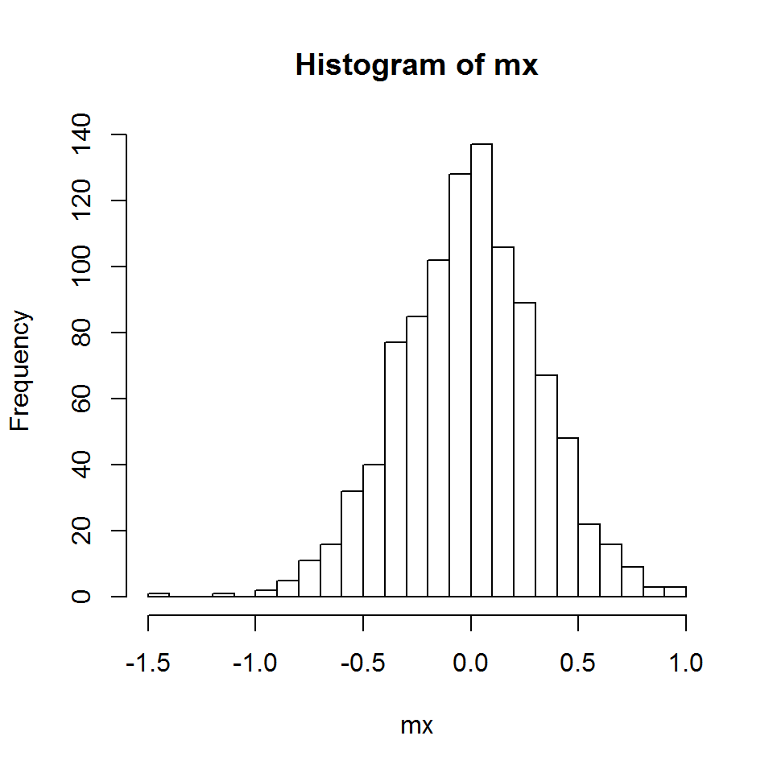

```r
hist(mx,nclass=20)
```

## 1.4 Notaion

Throughout out the book we keep, as much as we can, the notion presented in the book of Efron and Tibshirani (1993) “An Introduction to the Bootstrap”.

## 1.5 Just do it

If you did not have a problem to understand the R code above, you will not have any problem to understand the R code that we use to produce all the output for the examples discussed in this book. If you had a difficulty to understand the ``for loop’’ example above you need a short training, at a beginner level, in R.

### 1.5.1 YouTube tutorial: the for loop in R

For a short online YouTube introduction by Richard Webster about a for loop in R see [YTBootstrap 1](https://www.youtube.com/watch?v=h987LWDvqlQ).

### 1.5.2 R course online

An introductory course for R is able online in the >eR-BioStat website. See [Rcourse](https://github.com/eR-Biostat/Courses/tree/master/Introductory%20Courses/Introduction%20to%20R/Slides).

# 2 The empirical distribution function and the plug-in principle

In the first part of this book we cover basic concept that will be used in different chapters I the book:

- Sampling from a population.
- The plug-in principle.
- The empirical distribution.
- The accuracy of the sample mean a, the standard error and estimated standard error.

## 2.1 Slides

Slides for the first part that covers the topics of sampling for a population, the accuracy of the sample means and the glug-in principle can be found here: [Slides1](https://github.com/eR-Biostat/Courses/blob/master/Data%20Analysis/Resampling%20and%20bootstrap%20methods%20using%20R/Slides/CIM_Part1a_May_2020_V1.pdf).

## 2.2 Sampling for a population

Let $x_1, \ldots, x_n$ be a random sample from a probability distribution $F$ and let $\theta = \theta(F)$ be a parameter of interest. For example, let $F$ be a standard normal distribution, $F=N(\mu=0,\sigma^{2}=1)$ and consider a sample of 1000 observations,

```r
x<-rnorm(1000,0,1)
```

The distribution of the sample is shown below

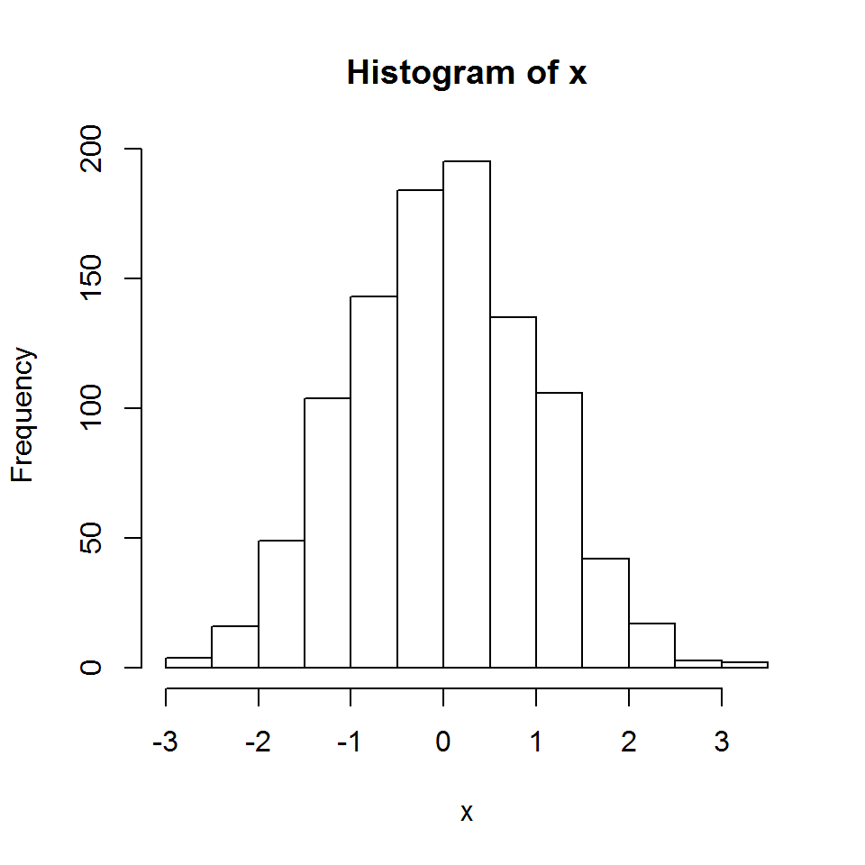

```r
hist(x)
```

The parameter of interest of the mean, $\mu=0$ and the parameter estimate $\hat{\mu}=\bar{x}$ is equal to

```r
mean(x)
```

```
## [1] -0.007070499
```

We note that $\bar{x}$ is defined on teh sample, that is $\hat{\mu}=\bar{x}= T(x_1, \ldots, x_n)$.

### 2.2.1 Example: the low school data

The law school data contain information about a random sample of size n=15 from the population of 82 USA law schools. The data consists of two measurements: LSAT (average score on a national law test) and GPA (average undergraduate grade-point average). The R object $law82S contains data for the whole population of 82 law schools. The left panel in the Figure below present the population of 82 scools while the right panel the random sample of 15 schools out the population.

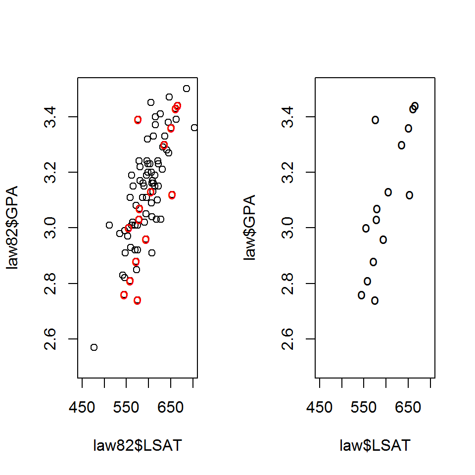

```r
par(mfrow=c(1,2))
plot(law82$LSAT,law82$GPA,xlim=c(450,700),ylim=c(2.5,3.5))
points(law$LSAT,law$GPA,pch="o",col=2)
plot(law$LSAT,law$GPA,pch="o",xlim=c(450,700),ylim=c(2.5,3.5))
```

The population correlation and the sample correlations.

```r
cor(law82$LSAT,law82$GPA)
```

```
## [1] 0.7599979
```

```r
cor(law$LSAT,law$GPA)
```

```
## [1] 0.7763745
```

## 2.3 The plug-in principle

Let $x_1, \ldots, x_n$ be a random sample from $F$, $\theta = t(F)$ the paramter of interest the plug-in estimate for $\theta$ is same function $t$ defined on the observed data (i.e., the emperical distribution,
$$\hat{\theta} = t(x_1, \ldots, x_n).$$
### Example: the low school data

For the low school example, the parameter of primary interest is the correlation between LAST and PGA in the population of the 82 schools

```r
cor(law82$LSAT,law82$GPA)
```

```
## [1] 0.7599979
```

while the plag-in estimate is the correlation between the two variables in the sample of 15 schools

```r
cor(law$LSAT,law$GPA)
```

```
## [1] 0.7763745
```

## 2.4 The empirical distribution

Let us assume that $x_1, \ldots, x_n$ is a random sample from a probability distribution $F(\theta)$. The empirical distribution function, $\hat{F}$ is defined to be the discrete distribution that puts probability of $\frac{1}{n}$ on each value of $x_{i}$. An example of a density function of $N(0,1)$ and an approximation of the density by a histogram is shown below.

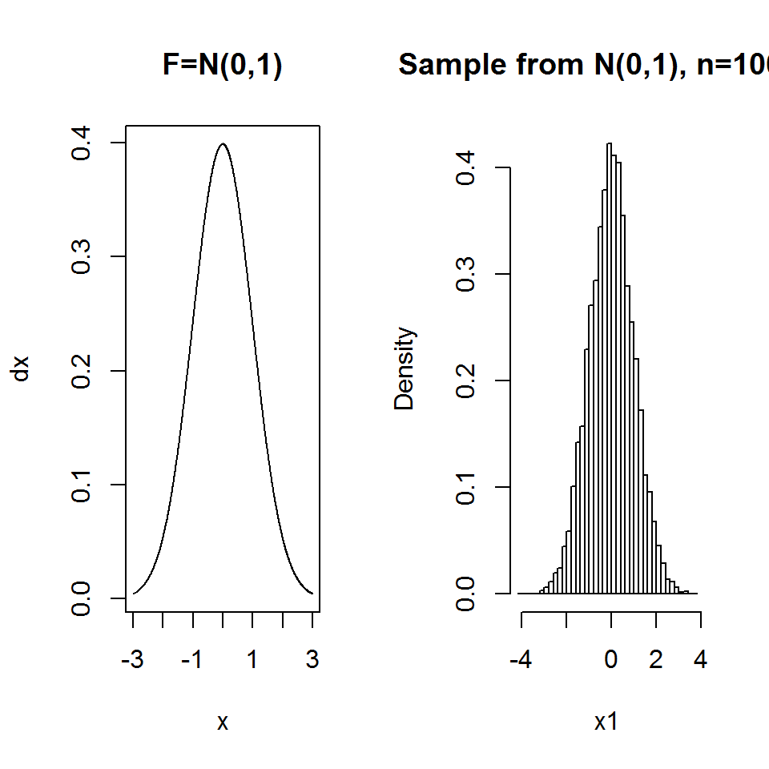

```r
par(mfrow=c(1,2))
x<-seq(from=-3,to=3,length=1000)
dx<-dnorm(x,0,1)
plot(x,dx,type="l")
title("F=N(0,1)")
x1<-rnorm(10000,0,1)
hist(x1,nclass=50,col=0,probability=T,main="Sample from N(0,1), n=10000")
```

As mentioned above, for a sample from $F$ of size $n$, the empirical distribution puts a probability of $\frac{1}{n}$ on each observations. Let $\hat{f_{k}}$ the observed frequency, $k=1,2,\dots K$,
$$\hat{f}_{k}=\frac{\#x=k}{n}.$$
The empirical distribution, $\hat{F}$ is given by
$$\hat{F}=(\hat{f}_{1},\dots,\hat{f}_{K}).$$

### 2.4.1 Example: $F=N(0,1)$, $n=50$

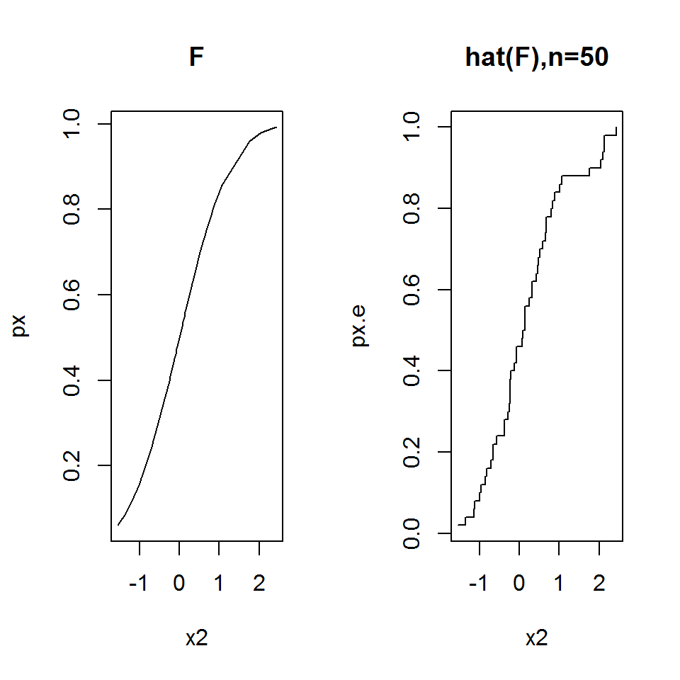

```r
par(mfrow=c(1,2))
x2<-rnorm(50,0,1)
x2<-sort(x2)
px<-pnorm(x2,0,1)
plot(x2,px,type="l")
title("F")
n<-length(x2)
px.e<-c(1:length(x2))/n
plot(x2,px.e,type="s")
title("hat(F),n=50")
```

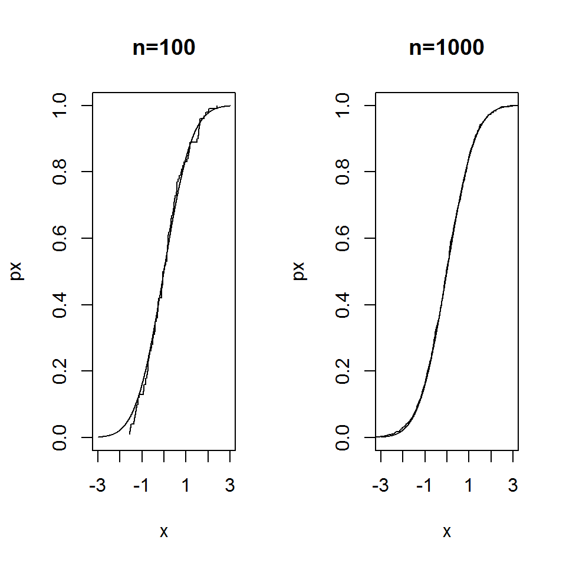

```r
par(mfrow=c(1,2))
x2<-rnorm(100,0,1)
x2<-sort(x2)
x<-seq(from=-3,to=3,length=1000)
px<-pnorm(x,0,1)
plot(x,px,type="l")
n<-length(x2)
px.e<-c(1:length(x2))/n
lines(x2,px.e,type="s")
title("n=100")
x2<-rnorm(1000,0,1)
x2<-sort(x2)
x<-seq(from=-3,to=3,length=1000)
px<-pnorm(x,0,1)
plot(x,px,type="l")
n<-length(x2)
px.e<-c(1:length(x2))/n
lines(x2,px.e,type="s")
title("n=1000")
```

# 3 The accuracy of the sample mean

Let $x_1, \ldots, x_n$ is a random sample from a probability distribution $F$.Let us assume that $\theta$ is the population mean and $\hat{\theta}$ is the sample mean. The variance of $\hat{\theta}$ is given by
$$Var(\hat{\theta})=\frac{\sigma^{2}}{n},$$
and it can be estimated by
$$\frac{s ^{2}}{n},\;\; s^{2}=\frac{1}{n-1}\sum_{i=1}^{n}\left (x_{i}-\bar{x} \right )^{2}.$$

## 3.1 Example: the mouse data

The mouse dataset is a small randomized experiment with 16 mouse, 7 belong to treatment group and 9 belong to control group. Treatment was intended to prolong survival time after a test surgery. Survival times for the control group are given by

```r
mouse.c
```

```
## [1]  52 104 146  10  50  31  40  27  46
```

```r
mean(mouse.c)
```

```
## [1] 56.22222
```

and the survival times for the treatment group are

```r
mouse.t
```

```
## [1]  94 197  16  38  99 141  23
```

```r
mean(mouse.t)
```

```
## [1] 86.85714
```

The standard error of the standard error of the sample mean is given by
$$\sqrt{\frac{\sigma^{2}}{n}}$$
Fo the mouse data the standard error for the two groups is given, respectivly by

```r
sqrt(var(mouse.c)/9)
```

```
## [1] 14.13897
```

```r
sqrt(var(mouse.t)/7)
```

```
## [1] 25.23549
```

## 3.2 Example: a random samples from $N(0,1)$

let us consider a random sample for $N(0,1)$ with $n=100$,

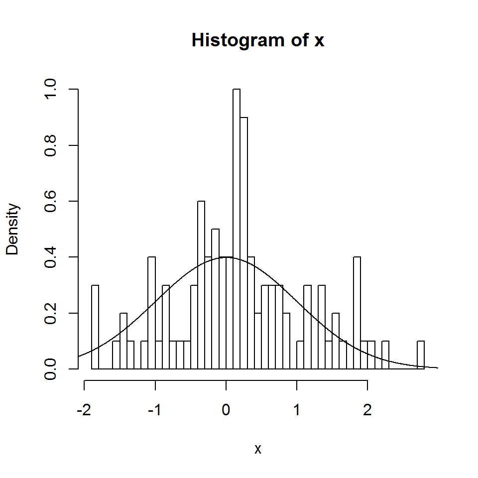

```r
x<-rnorm(100,0,1)
hist(x,nclass=50,probability=TRUE)
x1<-seq(from=-3,to=3,length=1000)
dx<-dnorm(x1,0,1)
lines(x1,dx)
```

The sample mean is equal to

```r
mean(x)
```

```
## [1] 0.1706321
```

Supose that we can resample 10000 samples of size 100 from $N(0,1)$ and estimate the mean with the sample mean $\bar{x}$.

```r
mx<-c(1:10000)
for(i in 1:10000)
{
x<-rnorm(100,0,1)
mx[i]<-mean(x)
}
```

We now can estimate the distribution of $\bar{x}$ based on the estimated value for $\mu$, $\bar{x}_{1},\dots,\bar{x}_{10000}$.

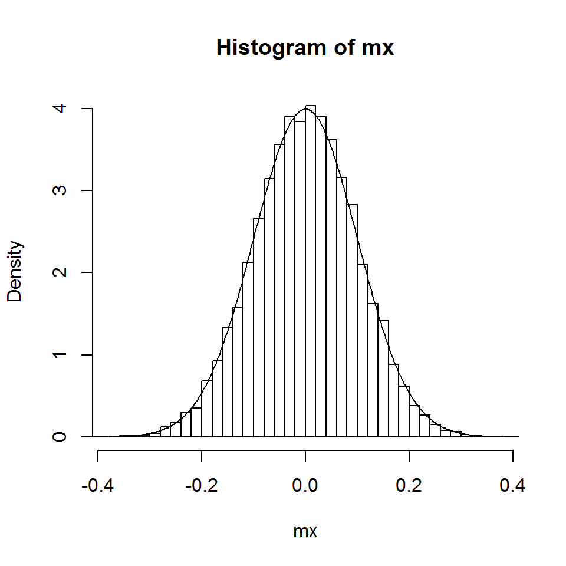

```r
hist(mx,nclass=50,probability=TRUE)
x1<-seq(from=-1,to=1,length=1000)
dx<-dnorm(x1,0,sqrt(1/100))
lines(x1,dx)
```

Note that the standard error of $\bar{x}$, since $\sigma^{2}=1$ and $n=100$ is equal to
$$\sqrt{\frac{1}{100}}=0.1$$

For our example the mean of $\bar{x}$ over the 10000 similated datasets is

```r
mean(mx)
```

```
## [1] 3.834859e-05
```

and the variance and standard error is given by

```r
var(mx)
```

```
## [1] 0.00970706
```

```r
sqrt(var(mx))
```

```
## [1] 0.09852441
```

very closed to the theoretical value of 0.1.

# 4 The bootstrap estimate of the standard error for the mean.

The bootstap is a computer-intensive statistical method that can be used to

- Estimate variability of estimators.
- Estimate probabilities and quantiles related to test statistics or to construct confidence  
  Intervals.
- explore the shape of the distribution of estimators or test statistics

The basic idea behind the bootstrap is that, given a sample from $F(\theta)$, we repeatedly sampling from $\hat{F}$ in order to approximate the distribution of $\hat{\theta}$. In this chapter we focus on the estimation of the standard error of the sample mean $\bar{x}$. We discuss two bootstrap procedures:

- Parametric bootstrap.
- Non parametric bootstrap.

Although we mainly discuss the problem of estimation of the standard errors of sample mean, the method is developed to be fully automatic and can be applied for any estimator of interest./newline

## 4.1 Slides

Slides for the second part of the book that covers the topic of the basic bootstrapcan be found here: [Slides2](https://github.com/eR-Biostat/Courses/blob/master/Data%20Analysis/Resampling%20and%20bootstrap%20methods%20using%20R/Slides/CIM_Part1b_May_2020_V1.pdf).

## 4.2 YouTube tutorial: the sample function in R

The non parametric bootstrap procedures discussed in this book are based on a for loop in which the resampling is done using the R function. A YouTube tutorial of Ian Dworkin is focused on the function in R can be found here:[YTBootstrap 2](https://www.youtub%20e.com/watch?v=xE3KGVT6VLE&t=17s).

## 4.3 YouTube tutorial: the basic basic bootstrap

For a short online introduction by Dr. Sarveshwar Inani about the basic bootstrap procedures and the implementation in R see [YTBootstrap 3](https://www.youtube.com/watch?v=tb6wb9ZdPH0).

## 4.4 Notaion

Let $F$ be a probability distribution function with unknown parameters $\theta$. Let $x_1, \ldots, x_n$ be a random sample from $F$, $\theta = t(F)$ is the parameter(s) of primary interest and $\hat{\theta} = t(x_1, \ldots, x_n)$ is the plug-in estimate for $\theta$. Our aim in this chapter is to estimate the standard error and the distribution of $\hat{\theta}$.

## 4.5 Non parametric bootstap

The Non parametric bootstrap algorithm consists of sampling for the empirical distribution $\hat{F}$. And it is defined as follows:

- Draw $B$ bootstrap samples $x^{*}(b) =(x_1^{*}(b), \dots, x_n^{*}(b))$, with replacement from (the empirical distribution) $x_1, \dots, x_n$ ($b=1,\dots B$).
- Evaluate the bootstrap replications

$$\hat{\theta}^*(b) = T(x^{*(b)}) \;\; b=1,\dots,B$$

- Estimate $se_F(\hat{\theta})$, $se_{\hat{F}_n}(\hat{\theta}^*)$ by the sample deviation of the $B$ replications

$$\hat{se}_B = \sqrt{\frac{1}{B-1} \sum_{i=1}^B[\hat{\theta}^*(b) - \hat{\theta}^{*}(.)]^2}$$
where
$$\hat{\theta}^{*}(.) = \frac{1}{B} \sum_{b=1}^B \hat{\theta}^*(b).$$

### 4.5.1 Example: Estimation of the standard error of the sample mean using non parametric bootstrap

Consider a sample of 10 observations form an unknown distribution

```r
x <- c(11.201, 10.035, 11.118, 9.055, 9.434, 9.663, 10.403, 11.662, 9.285,8.84)
```

```r
var(x)
```

```
## [1] 0.9726152
```

```r
var(x)/10
```

```
## [1] 0.09726152
```

```r
n<-length(x)
```

Non parametric bootstrap algorethim consists of resampling $B$ bootstrap samples from $\hat{F}$. For the $b$th bootstrap sample we use the function

```r
B<-1000
mx<-c(1:B)
for(i in 1:B){
boot.i<-sample(x,n,replace=T)
mx[i]<-mean(boot.i)
}
```

Note that the R object is used to store the bootstrap replicates, =$(\hat{\theta}^{*}_{1},\dots,\hat{\theta}^{*}_{B})$ . A bootstrap estimate for the distribution of $\hat{\mu}=\bar{x}$ is shown below.

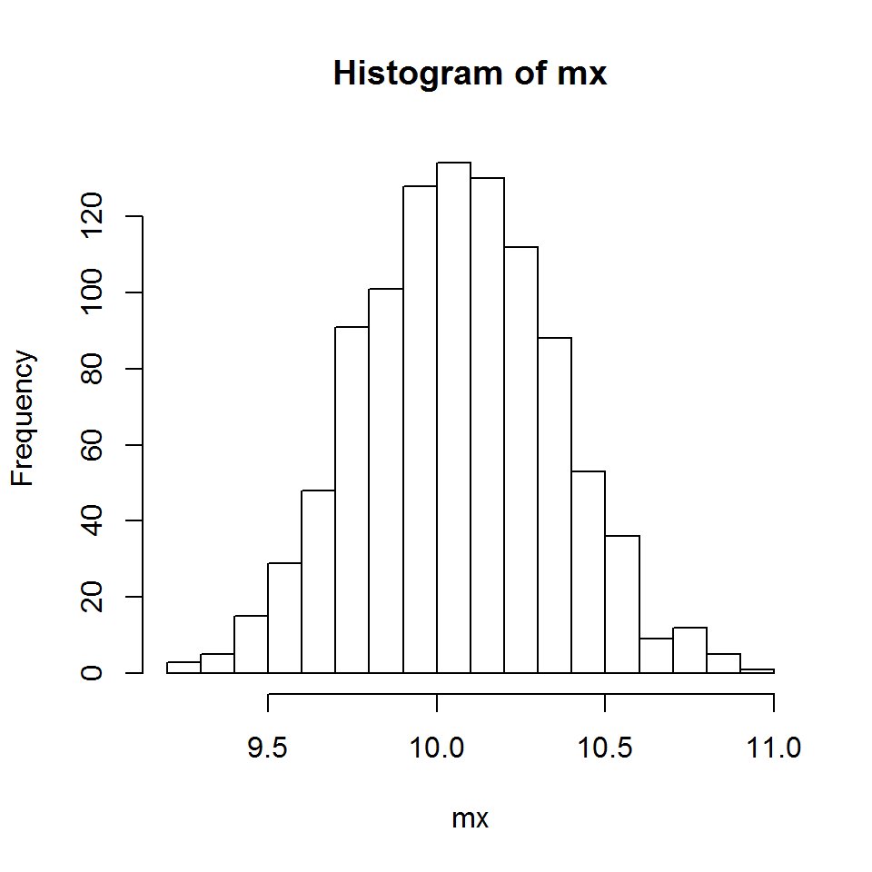

```r
hist(mx,nclass=20)
```

```r
var(mx)
```

```
## [1] 0.08216878
```

## 4.6 Parametric bootstap

Let $F(\theta)$ the probability function of interest. The parametric bootstrap estimate of the standard error of $\hat{\theta}$ is defined as
$$se_{\hat{F}_{prm}}(\hat{\theta}^{*}),$$

Here, $\hat{F}_{prm}$ is a parametric distribution that we used for $F(\theta)$. Note that since $\theta$ is an unknown parameter, we use the plag-in estimate $\hat{\theta}$. The parametric bootstrap algorithm is as follow:

- Make a parametric assumption about the probability distribution $F$.
- Estimate $\theta$ from the sample using the plug-in estimate $\hat{\theta}$.
- Draw $B$ bootstrap samples (of size $n$) from $F(\hat{\theta})$.
- Evaluate the bootstrap replications

$$\hat{\theta}^*(b) = T(x^{*(b)}) \;\; b=1,\dots,B$$

- Estimate $se_F(\hat{\theta})$, $se_{\hat{F}_n}(\hat{\theta}^*)$ by the sample deviation of the $B$ replications

$$\hat{se}_B = \sqrt{\frac{1}{B-1} \sum_{i=1}^B[\hat{\theta}^*(b) - \hat{\theta}^{*}(.)]^2}$$
where
$$\hat{\theta}^{*}(.) = \frac{1}{B} \sum_{b=1}^B \hat{\theta}^*(b).$$

### 4.6.1 Example: Estimation of the standard error of the sample mean using parametric bootstrap

Let us assume that the sample $x_{1},\dots,x_{n}$ was drawn from $N(\mu,\sigma^{2})$.Since $\mu$ and $\sigma^{2}$ are unknown we estimate both parameters using thier plug-in estimates,

```r
MLx<-mean(x)
MLx
```

```
## [1] 10.0696
```

```r
Varx<-var(x)
Varx
```

```
## [1] 0.9726152
```

```r
B<-1000
mx<-c(1:B)
for(i in 1:B){
boot.i<-rnorm(n,MLx,sqrt(Varx))
mx[i]<-mean(boot.i)
}
```

A bootstrap estimate for the distribution of $\hat{mu}=\bar{x}$

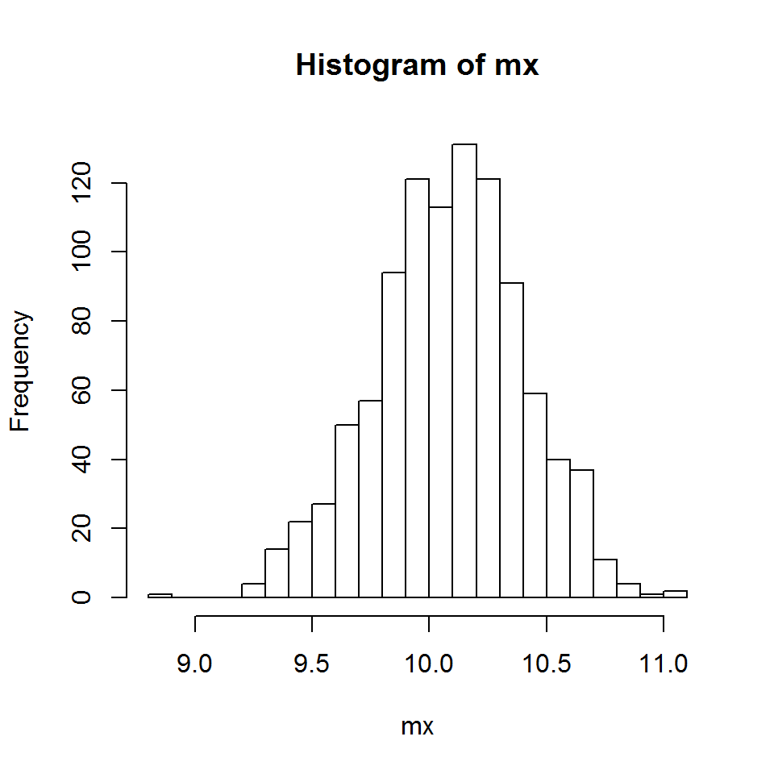

```r
hist(mx,nclass=20)
```

```r
var(mx)
```

```
## [1] 0.09884198
```

# 5 Example: the correlation coefficient.

## 5.1 YouTube tutorial: resampling pairs

The resampling procedure discussed in this section is required to re sample pairs of observations ($x_{i},y_{i}$) in order to keep the correlation stricture of the data. For a short online introduction, by Ian Dworkin, about the $sample$ function in R and how to resample pairs (start at the end of the tutorial at $5:45$), see [YTBootstrap 3](https://www.youtube.com/watch?v=xE3KGVT6VLE).

## 5.2 Estimating the distribution of the sample correlation with bootstrap

Consider the following data (Neter et al.~(1996), p. 653) on population (in thousands) and expenditures for a new food product (per capita in dollars)

```r
#x:population (in thousands)
#y:expenditures
x<-c(29,435,86,1090,219,503,47,3524,185,98,952,89)
y<-c(127,214,133,208,153,184,130,217,141,154,194,103)
cbind(x,y)
```

```
##          x   y
##  [1,]   29 127
##  [2,]  435 214
##  [3,]   86 133
##  [4,] 1090 208
##  [5,]  219 153
##  [6,]  503 184
##  [7,]   47 130
##  [8,] 3524 217
##  [9,]  185 141
## [10,]   98 154
## [11,]  952 194
## [12,]   89 103
```

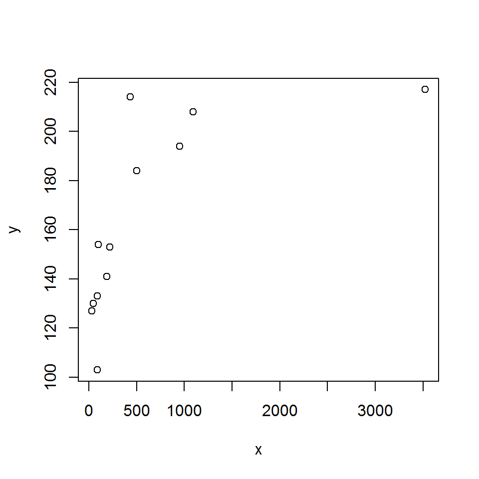

```r
plot(x,y)
```

```r
cor.obs<-cor(x,y)
```

The parameter of interest is the correation between the population and expenditures, $\rho(x,y)$. The sample correlation, $\hat{\rho}(x,y)$, is equal to

```r
cor.obs
```

```
## [1] 0.6737664
```

## 5.3 Non parametric bootstrap

Our aim is to estimate the standard error and the distribution of the corelation. A non parametric bootstrap consists of resampling pairs from the bivariate data $(x_{i},y_{i})$. Since we would like the correlation structure as it is in the sample, we need to resample pairs. This implies that within the bootstrap loop the observation $(x_{i},y_{i})$ will resample together. This can be done using an index vector:

```r
n<-length(x)
n
```

```
## [1] 12
```

```r
index<-c(1:n)
index
```

```
##  [1]  1  2  3  4  5  6  7  8  9 10 11 12
```

For the bootstrap we use the following code:

```r
B<-1000
obs.8<-cor.xy<-c(1:B)
for(i in 1:B)
{
boot.i<-sample(index,n,replace=T)
obs.8[i]<-sum(boot.i==8)
x.b<-x[boot.i]
y.b<-y[boot.i]
cor.xy[i]<-cor(x.b,y.b)
}
```

The distribution of the bootstrap rplicates is an estimate for the distribution of $\hat{\rho(x,y)}$

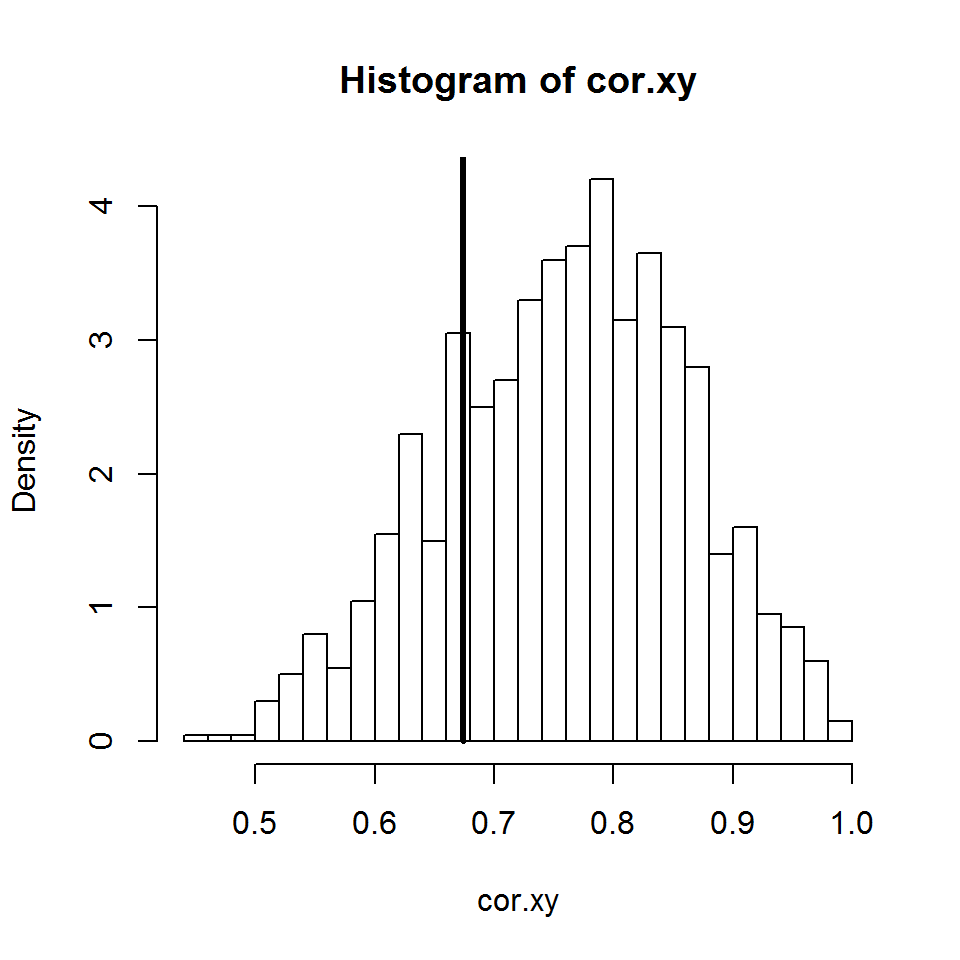

```r
hist(cor.xy,probability=T,col=0,nclass=30)
lines(c(cor.obs,cor.obs),c(0,10),lwd=3)
```

The standard error of $\hat{\rho}$ is given by

```r
sqrt(var(cor.xy))
```

```
## [1] 0.1020551
```

## 5.4 Parametric bootstrap

For the parametric bootstrap we assume that the joint distribution of $x$ and $y$ is bivariate normal distribution given by

$$\left (
\begin{array}{l}
x \\
y
\end{array}
\right ) \sim N \left (
\left (
\begin{array}{l}
\mu_x \\
\mu y
\end{array}
\right ), \Sigma
\right ).$$

Here, $\Sigma$ is a $2 \times 2$ the covariance matrix given by

$$\Sigma= \left (
\begin{array}{ll}
\sigma^{2}_{x} & cov(x,y) \\
cov(x,y) & \sigma^{2}_{y}
\end{array}
\right ).$$

Since all the parameters are unknown we use their plug-in estimates $\hat{\mu}_{x}$ (MLx),$\hat{\mu}_{y}$ (MLy) and $\hat{\Sigma}$ (sigma).

```r
cor.obs<-cor(x,y)
dat.mat<-cbind(x,y)
n<-length(x)
MLx<-mean(x)
MLy<-mean(y)
sigma<-cov(dat.mat)
```

The code for the parametric bootstrap is given below.

```r
B<-1000
cor.xy<-c(1:B)
for(i in 1:B)
{
dat.b <- rmvnorm(n=n, mean=c(MLx,MLy),sigma=sigma)
cor.xy[i]<-cor(dat.b)[1,2]
}
```

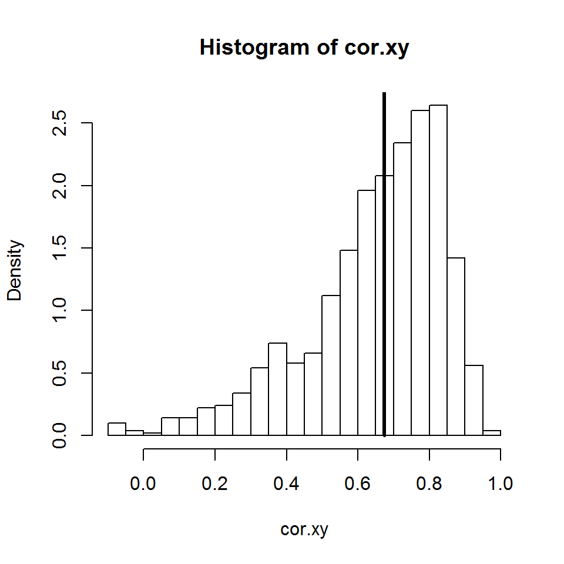

```r
hist(cor.xy,probability=T,col=0,nclass=30)
lines(c(cor.obs,cor.obs),c(0,10),lwd=3)
```

# 6 Example: the airquality data.

The airquality data gives information about the daily air quality measurements in New York, May to September 1973. For the analysis presented below we focus on the mean ozone in parts per billion from 1300 to 1500 hours at Roosevelt Island.

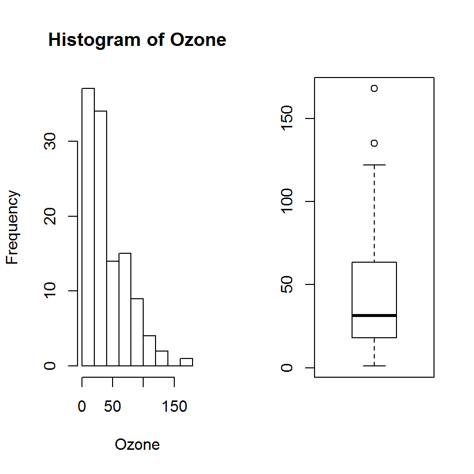

```r
par(mfrow=c(1,2))
attach(airquality)
Ozone<-na.omit(Ozone)
hist(Ozone)
boxplot(Ozone)
```

The parameter of primiry interest are the $25\%,50\%$ and $75\%$ quantile of the ozone distribution. The sample quantiles are equal to

```r
quantile(Ozone,probs=c(0.25,0.5,0.75))
```

```
##   25%   50%   75%
## 18.00 31.50 63.25
```

To calculate the standard error of the quantiles we implement a non parametruc bootstrap procedure.

```r
B<-10000
q.boot<-matrix(0,B,3)
for(b in 1:B)
{
Ozone.boot<-sample(Ozone,size=116,replace=TRUE)
q.boot[b,]<-quantile(Ozone.boot,probs=c(0.25,0.5,0.75))
}
```

Boxplot for the quantiles’ distribution is shown below.

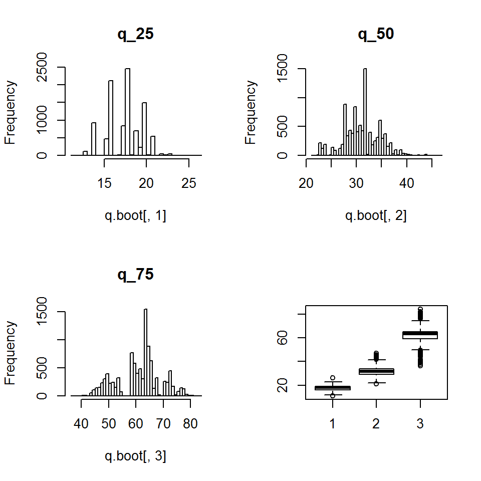

```r
par(mfrow=c(2,2))
hist(q.boot[,1],nclass=50,main="q_25")
hist(q.boot[,2],nclass=50,main="q_50")
hist(q.boot[,3],nclass=50,main="q_75")
boxplot(q.boot[,1],q.boot[,2],q.boot[,3])
```

# 7 Example: the score data.

The score dataset provides information about 88 students who took examinations in 5 subjects. Some where with open book and other with closed book.The first 6 students and the boxplot for the scores are shown below

```r
head(scor)
```

```
##   mec vec alg ana sta
## 1  77  82  67  67  81
## 2  63  78  80  70  81
## 3  75  73  71  66  81
## 4  55  72  63  70  68
## 5  63  63  65  70  63
## 6  53  61  72  64  73
```

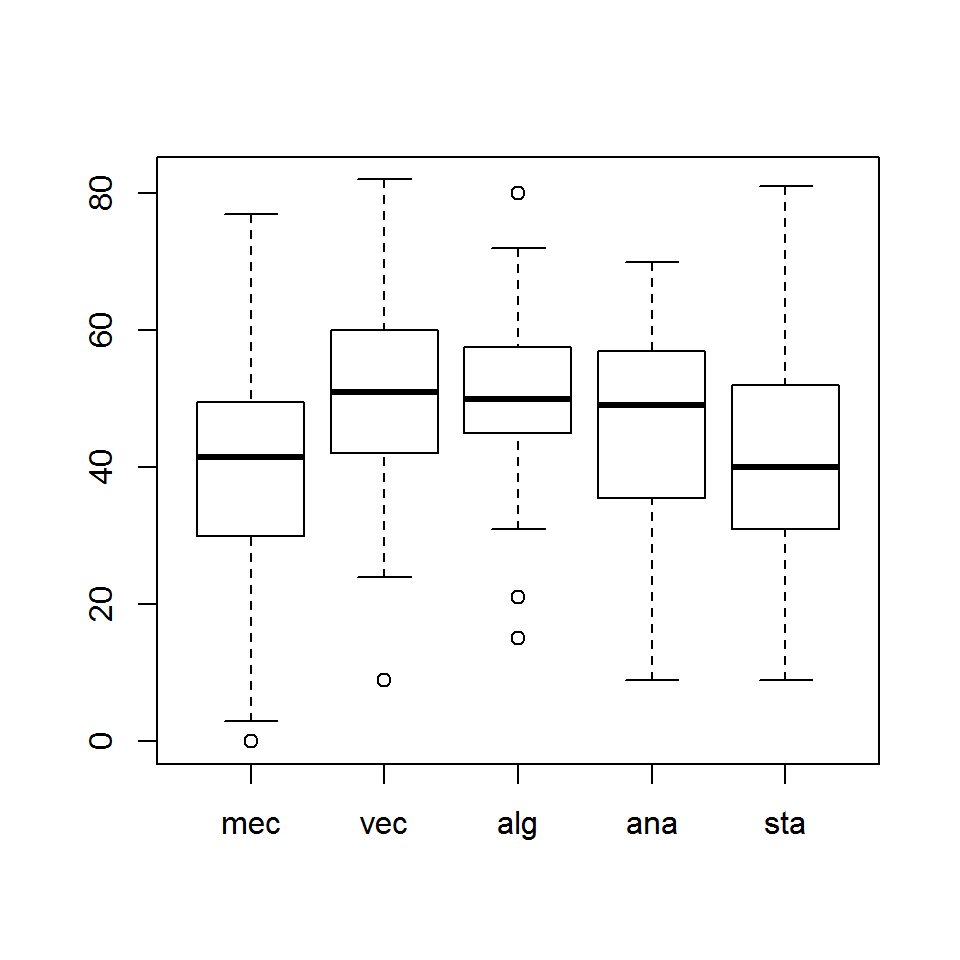

```r
boxplot(scor)
```

Our main interst is the covariance between the results in statistics and algebra. Corelation amtrix is given by

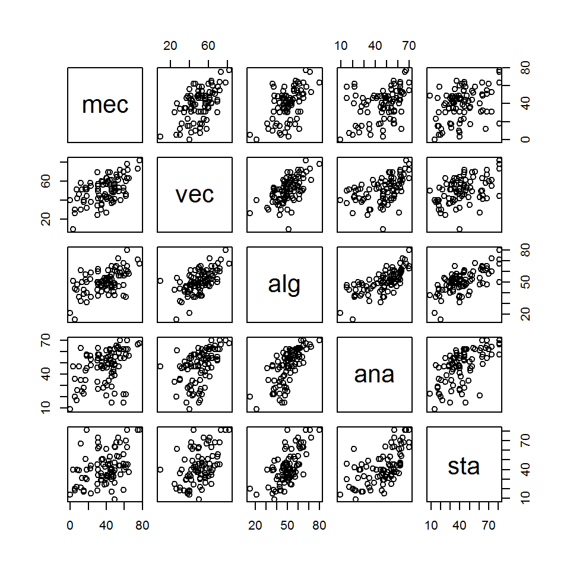

```r
pairs(scor)
```

```r
cov(scor)
```

```
##          mec       vec       alg       ana       sta
## mec 305.7680 127.22257 101.57941 106.27273 117.40491
## vec 127.2226 172.84222  85.15726  94.67294  99.01202
## alg 101.5794  85.15726 112.88597 112.11338 121.87056
## ana 106.2727  94.67294 112.11338 220.38036 155.53553
## sta 117.4049  99.01202 121.87056 155.53553 297.75536
```

The sample covariance between statistics and algebra is equal to

```r
cov(scor)[3,5]
```

```
## [1] 121.8706
```

To estimate the distribution and the standard error of $\Sigma_{3,5}$ we conduct a non parametric bootstrap of 1000 steps. Note that the R object $sig35$ contains the bootstrap replicates for $\Sigma^{*}_{3,5}$.

```r
n<-length(scor$sta)
B<-1000
index<-c(1:n)
sig35<-ratio.b<-c(1:B)
for(i in 1:B)
{
index.b<-sample(index,n,replace=TRUE)
scor.b<-scor[index.b,]
cov.b<-cov(scor.b)
sig35[i]<-cov.b[5,3]
ratio.b[i]<-mean(scor.b$sta/scor.b$alg)
}
```

The distribtuion of the bootstarp replicates is given below

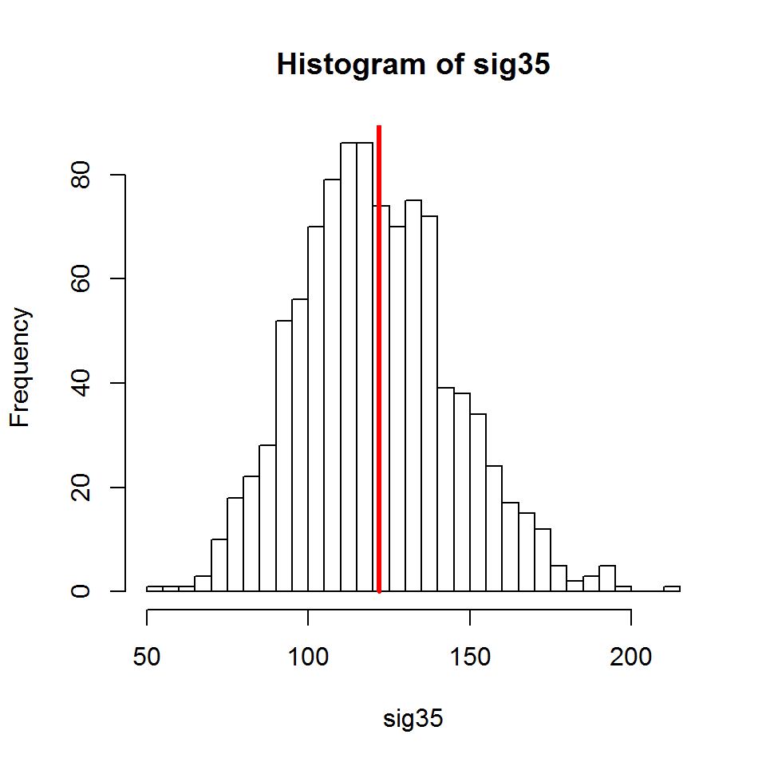

```r
hist(sig35,nclass=50)
lines(c( 121.8706,121.8706),c(0,500),col=2,lwd=3)
```

Standard error for $\hat{\Sigma}_{3,5}$ is equal to

```r
var(sig35)
```

```
## [1] 571.3862
```

```r
sqrt(var(sig35))
```

```
## [1] 23.90369
```

# 8 Classical confidence intervals

Let $\hat{\theta}$ be an estimator for some parameter $\theta$ (based on a sample of size $n$) and suppose we want an interval with left- and right-tail errors equal to $\alpha$. Let the respective quantiles of $\hat{\theta}-\theta$ be defined as

$$P(\hat{\theta}-\theta \leq \xi_\alpha) = \alpha = P(\hat{\theta}-\theta \geq \xi_{1-\alpha}).$$

Then the $(1-2\alpha)100\%$ equi-tailed interval is given by

$$[\hat{\theta}-\xi_{1-\alpha}, \hat{\theta}-\xi_\alpha].$$

Usually the distribution and hence the quantiles of $\hat{\theta}-\theta$ are unknown and have to be estimated using the bootstrap. As in many situations, both the parametric and the nonparametric bootstrap can be used for these purposes.

First we consider a special case where the distribution of $\hat{\theta} - \theta$ is assumed to be (approximately) normal.

## 8.1 Example: the mouse data - classical C.I using $N(0,1)$

We consider the treatment group of the mouse data for which $\bar{z}=86.85714$.

```r
z <- c(94, 197, 16, 38, 99, 141, 23)
z
```

```
## [1]  94 197  16  38  99 141  23
```

```r
t.hat<-mean(z)
se.t.hat<-sqrt(var(z)/7)
t.hat
```

```
## [1] 86.85714
```

```r
se.t.hat
```

```
## [1] 25.23549
```

Let us assume that $Z_{i}\sim N(\mu,\sigma^{2})$. In this case the $(1-\alpha) \times 100\%$ confidence intervals is given by

$$(\hat(\theta)-\frac{\sigma}{\sqrt{n}} \times C_{\alpha},\hat(\theta)+\frac{\sigma}{\sqrt{n}} \times C_{\alpha}).$$

Here, $C_{\alpha}$ is the quantile for the $N(0,1)$ distribution that satisfies

$$P(Z \le C_{\alpha})=1-\frac{\alpha}{2}$$
For $\alpha=0.1$, the critical value (the $95\%$ quantile of $N(0,1)$) is equal to

```r
C.alpha<-qnorm(0.95,0,1)
C.alpha
```

```
## [1] 1.644854
```

and it is shown in the Figure below.

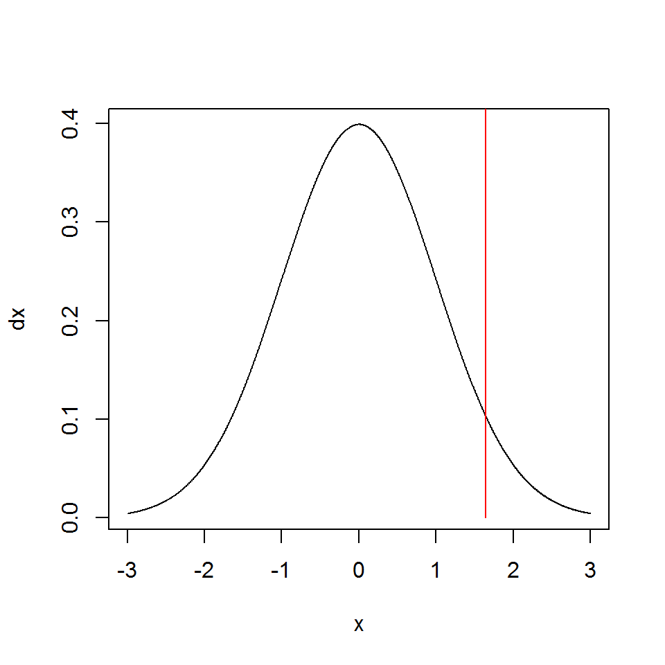

```r
x<-seq(from=-3,to=3,length=1000)
dx<-dnorm(x,0,1)
plot(x,dx,type="l")
lines(c(C.alpha,C.alpha),c(0,1),col=2)
```

Thus, a $90\%$ C.I for the mean is given by

```r
c(t.hat-se.t.hat*C.alpha,t.hat+se.t.hat*C.alpha)
```

```
## [1]  45.34846 128.36583
```

## 8.2 Example: the mouse data - classical C.I using t distribution

Alternativly, we can use a $t_{6}$ to choose the quantile for the C.I. In this case a $90\%$ C.I for the mean is given by

```r
t.test(z,conf.level=0.9)
```

```
##
##  One Sample t-test
##
## data:  z
## t = 3.4419, df = 6, p-value = 0.01377
## alternative hypothesis: true mean is not equal to 0
## 90 percent confidence interval:
##   37.82004 135.89425
## sample estimates:
## mean of x
##  86.85714
```

# 9 Bootstrap confidence intervals

The main idea behind the bootstrap confidence intervals is to avoid the parametric assumption about the distribution of $\hat{\theta}-\theta$ and to estimate the distribution using bootstrap techniques. Both the parametric and non-parametric bootstrap procedures, discussed in the previous part of the book, can be used.

## 9.1 YouTube tutorial: bootstrap confidence intervals

A very basic YouTube tutorial by Matthew E. Clapham is focused on a non parametric bootstrap procedure in R for the calculation of confidence intervals for the mean. See [YTBootstrap 4](https://www.youtube.com/watch?v=gcPIyeqymOU).

## 9.2 Improved normal confidence intervals

Suppose $\hat{\theta}-\theta$ is (approximately) normal, so
$$\hat{\theta} \sim N(\beta, \nu),$$
where $\beta$ represents the (asymptotic) bias
$$\beta = E(\hat{\theta}) - \theta,$$
and $\nu$ the (asymptotic) variance $\nu = Var(T)$. In case $\beta$ and $\nu$ are known, a $(1-2\alpha)100\%$ confidence interval for $\theta$ is given by
$$(t - \beta - C_\alpha \sqrt{\nu}, t - \beta - C_\alpha \sqrt{\nu}),$$

where $\Phi(C_\alpha) = 1-\alpha$.But usually bias and variance are unknown. Conditional on the observed sample, bias and variance of $\hat{\theta}$ can be estimated using the actual value of the parameter estimate and a set of bootstrap replicates $\hat{\theta}^{*}_{b}, b= 1, \ldots, B$
$$\hat{\beta} = \bar{\hat{\theta}}^{*} - \hat{\theta} = B^{-1}\sum_{b=1}^B \hat{\theta}^{*}_{b} - \hat{\theta}$$

The standard error can be estimated by

$$\hat{\nu} = (B-1)^{-1} \sum_{b=1}^B (\hat{\theta}^{*}_{b} -\bar{\hat}{\theta}^{*})^2$$
leading to the confidence interval

$$(\hat{\theta} - \hat{\beta} +C_\alpha \sqrt{\hat{\nu}}, \hat{\theta} - \hat{\beta} -C_\alpha \sqrt{\hat{\nu}}).$$

### 9.2.1 Example: the mouse data

In the first stage we implement a non parametric bootstrap,

```r
B=10000
t.boot<-c(1:B)
for(b in 1:B)
{
x.boot<-sample(z,size=length(z),replace=T)
t.boot[b]<-mean(x.boot)
}
```

The R object $t.boot$ is use to store the bbotsrrap replicates. The bias estimate is calculated by

```r
bias.t<-mean(t.boot)-t.hat
bias.t
```

```
## [1] -0.3280286
```

The distribution of the bootstrap replicates is shown below

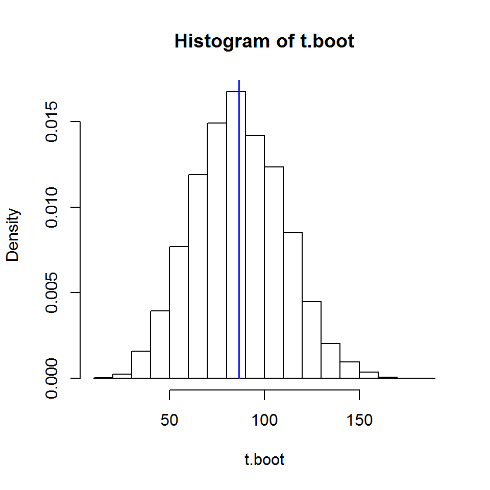

```r
hist(t.boot,nclass=20,col=0,probability=TRUE)
lines(c(t.hat,t.hat),c(0,20),col=2)
lines(c(mean(t.boot),mean(t.boot)),c(0,20),col=4)
```

The bootstrap estimate for the standard error of the sample mean is equal to

```r
vt<-sqrt(var(t.boot))
vt
```

```
## [1] 23.55246
```

A $90\%$ C.I is give by

```r
C.alpha<-qnorm(0.95,0,1)
C.alpha
```

```
## [1] 1.644854
```

```r
c(t.hat-bias.t-se.t.hat*C.alpha,t.hat-bias.t+se.t.hat*C.alpha)
```

```
## [1]  45.67648 128.69386
```

## 9.3 Basic bootstrap intervals

Without any distributional assumptions on $\hat{\theta}$, basic bootstrap intervals can be based on bootstrap estimates for the quantiles $\xi_{1-\alpha}$ and $\xi_\alpha$. Indeed one can use the corresponding quantiles of $\hat{\theta}^{*}-\hat{\theta}$ which can be approximated by simulation, leading to the confidence interval

$$(2\hat{\theta}-\hat{\theta}^{*}_{((B+1)(1-\alpha))}, 2\hat{\theta}-\hat{\theta}^{*}_{((B+1)(\alpha))})$$

where $\hat{\theta}^*_{(b)}, k=1, \ldots, B$ denote the ordered bootstrap replicates. Here and in the sequel, we assume that $B$ and $\alpha$ are chosen such that $(B+1)\alpha$ and $(B+1)(1-\alpha)$ are integers.

### 9.3.1 Example: the mouse data

Non papametric bootstrap procedure:

```r
B=10000
t.boot<-c(1:B)
for(b in 1:B)
{
x.boot<-sample(z,size=length(z),replace=T)
t.boot[b]<-mean(x.boot)
}
```

For a $90\%$ C.I, the $95\%$ and $5\%$ quantiles of the bootstrap replicates are given by

```r
t.up<-quantile(t.boot,probs=c(0.95))
t.lo<-quantile(t.boot,probs=c(0.05))
t.up
```

```
##      95%
## 126.7143
```

```r
t.lo
```

```
##       5%
## 50.14286
```

The upper and lower quantiles are shown below.

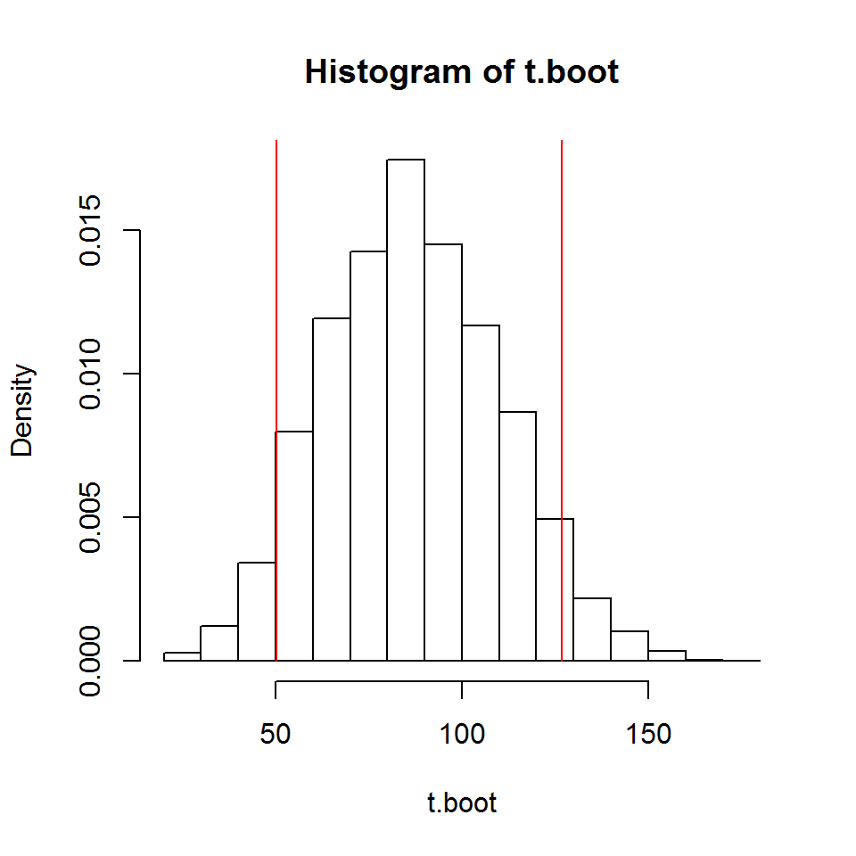

```r
hist(t.boot,nclass=20,col=0,probability=TRUE)
lines(c(t.up,t.up),c(0,20),col=2)
lines(c(t.lo,t.lo),c(0,20),col=2)
```

A $90\%$ C.I:

```r
c(2*t.hat-t.up,2*t.hat-t.lo)
```

```
##      95%       5%
##  47.0000 123.5714
```

## 9.4 Percentile intervals

Suppose that there is some unknown (monotonic & nondecreasing) transformation $U=h(\theta)$ which has a symmetric distribution. Using this symmetry, the $(1-2\alpha)100\%$ basic confidence interval for $\phi = h(\theta)$ is given is by
$$[L^*_{((B+1)\alpha)},U^*_{((B+1)(1-\alpha))}]$$
and by backtransformation for $\theta$ by
$$[\theta^*_{((B+1)\alpha)},\theta^*_{((B+1)(1-\alpha))}].$$
This kind of bootstrap interval was initially recommended in place of the basic bootstrap interval, but the method turned out not to work well for the nonparametric bootstrap (even when a suitable transformation $h$ exists). Adjusted percentile methods overcoming these difficulties are discussed in one of the next sections.

### 9.4.1 Example: percentile intervals for the mouse data

We use a non parametric bootstrap with $B=10000$ to approximate the distribution of $\hat{\theta}$.

```r
B=10000
t.boot<-c(1:B)
for(b in 1:B)
{
x.boot<-sample(z,size=length(z),replace=T)
t.boot[b]<-mean(x.boot)
}
```

A $90\%$ percentile interval is given by

```r
quantile(t.boot,probs=c(0.05,0.95))
```

```
##        5%       95%
##  49.14286 126.29286
```

This interval can visualize by

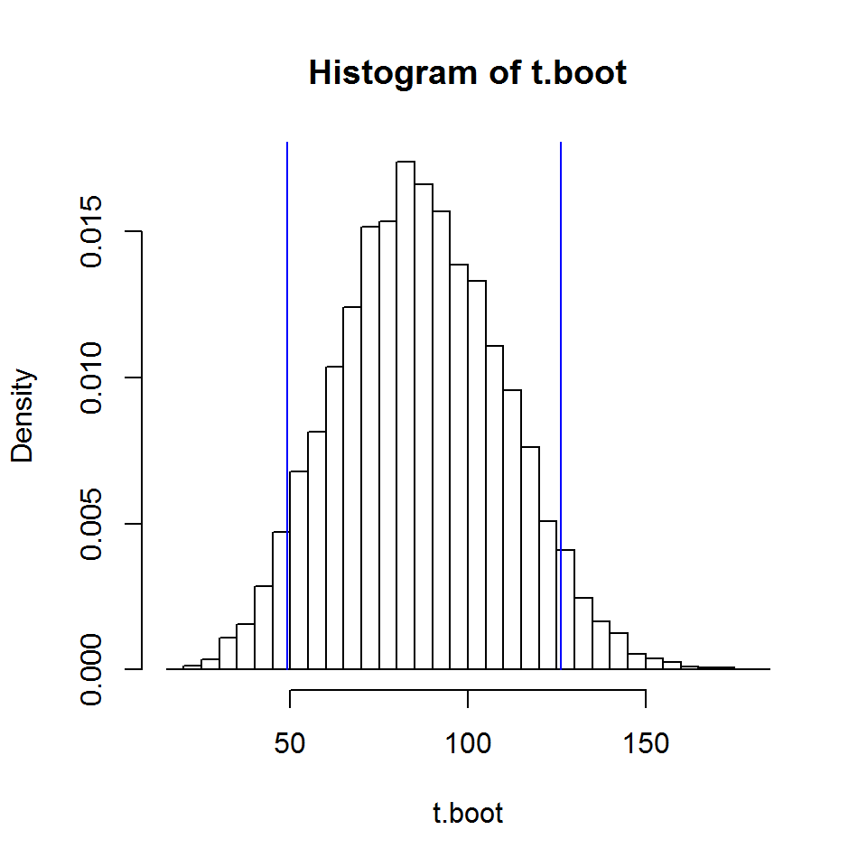

```r
lo<-quantile(t.boot,probs=c(0.05,0.95))[1]
up<-quantile(t.boot,probs=c(0.05,0.95))[2]
hist(t.boot,probability=T,nclass=50)
lines(c(lo,lo),c(0,0.2),col=4)
lines(c(up,up),c(0,0.2),col=4)
```

## 9.5 Bootstrap $t$ intervals

Instead of working with $\hat{\theta}-\theta$, these intervals start from a pivotal statistic such as
$$Z = \frac{\hat{\theta}-\theta}{\sqrt{V}},$$
where $V$ is an estimator for $\nu = Var(T)$.
The distribution of
$$Z^* = \frac{\hat{\theta}^*-\theta}{\sqrt{V^*}}$$
can then be used to estimate the quantiles of $Z$. Simulating $B$ bootstrap samples, this would lead to the interval
$$(\theta-\sqrt{v}z^*_{((1-\alpha)(B+1))},\theta-\sqrt{v}z^*_{(\alpha(B+1))}).$$
These are also known as ``Studentized intervals’’. The method is superior to the previous ones. But it needs a variance estimator and does not respect transfrmation of the form $\eta=h(\theta)$.

### 9.5.1 Example: the mouse data

Our starting point is a non parametric bootstrap with B=10000.

```r
B=10000
t.boot<-c(1:B)
for(b in 1:B)
{
x.boot<-sample(z,size=length(z),replace=T)
se.boot<-sqrt(var(x.boot)/length(z))
t.boot[b]<-(mean(x.boot)-t.hat)/se.boot
}
```

Quantiles for bootstrap replicates $z^{*}$ and for $t_{(6)}$ (note that $n=7$):

```r
quantile(t.boot,probs=c(0.05,0.95))
```

```
##        5%       95%
## -2.185415  1.738280
```

```r
qt(0.95,6)
```

```
## [1] 1.94318
```

```r
qt(0.05,6)
```

```
## [1] -1.94318
```

Histogram of the bootstrap replicates $z^{*}$ with density of $t_{(6)}$ and the quantiles:

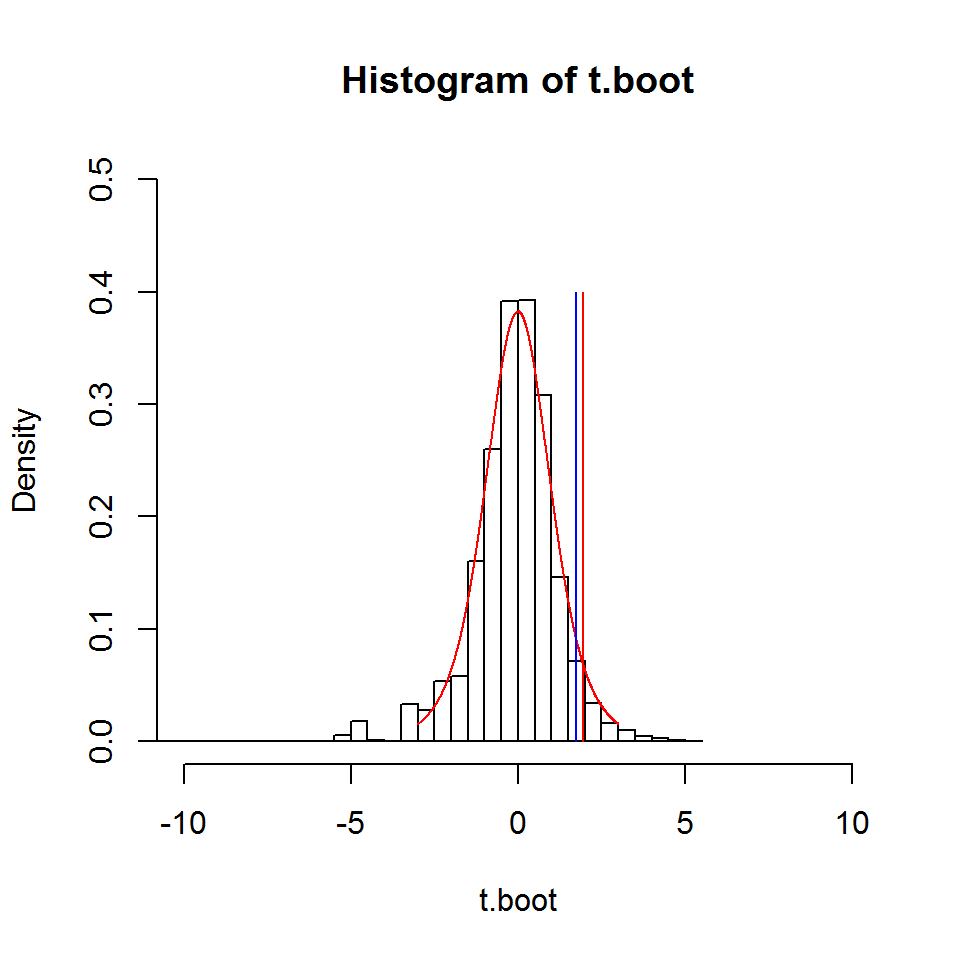

```r
hist(t.boot,probability=T,nclass=100,ylim=c(0,0.5),xlim=c(-10,10))
xx<-seq(from=-3,to=3,length=1000)
dx2<-dt(xx,6)
lines(xx,dx2,col=2)
lines(rep(qt(0.95,6),2),c(0,0.4),col=2)
calpha<-quantile(t.boot,probs=c(0.95))
lines(rep(calpha,2),c(0,0.4),col=4)
```

```r
qt(0.95,6)
```

```
## [1] 1.94318
```

```r
quantile(t.boot,probs=c(0.95))
```

```
##     95%
## 1.73828
```

The bootstrap t interval:

```r
up<-quantile(t.boot,probs=c(0.95))
lo<-quantile(t.boot,probs=c(0.05))
c(t.hat+se.t.hat*lo,t.hat+se.t.hat*up)
```

```
##        5%       95%
##  31.70712 130.72348
```

Confidence interval based on $t_{(6)}$ distribution.

```r
t.test(z,conf.level=0.9)
```

```
##
##  One Sample t-test
##
## data:  z
## t = 3.4419, df = 6, p-value = 0.01377
## alternative hypothesis: true mean is not equal to 0
## 90 percent confidence interval:
##   37.82004 135.89425
## sample estimates:
## mean of x
##  86.85714
```

## 9.8 The BCa method

The $BC_a$ interval is a bootstrap interval based on a percentile interval which is corrected for possible bias. Here the choices of $\alpha'$ and $\alpha''$ (for the quantiles to be used in the interval) are determined by

$$\alpha' = \Phi(\hat{b} + \frac{\hat{b}+z_\alpha}{1-\hat{a}(\hat{b}+z_\alpha)})$$

$$\alpha'' = 1-\Phi(\hat{b} + \frac{\hat{b}+z_{1-\alpha}}{1-\hat{a}(\hat{b}+z_{1-\alpha})})$$

where
$$\hat{b} = \Phi^{-1} \left (\frac{\#\{t^*_b < t\}}{B} \right )$$

and

$$\hat{a} = \frac{\sum_{i=1}^n(t^{(\cdot)}-t^{(-i)})^3}{6\{\sum_{i=1}^n(t^{(\cdot)}-t^{(-i)})^2\}^{3/2}}$$
with
$$t^{(\cdot)} = \frac{1}{n} \sum_{i=1}^n t^{(-i)}.$$
The bias-correction $\hat{b}$ measures the median bias of $t^*$. The acceleration $\hat{a}$ is based on so-called ``jackknife values’’ $t^{(-i)}$ and is called the acceleration because it refers to the rate of change of the standard error of $t$ with respect to the true parameter value $\theta$.

The $BC_a$ method has two advantages

### 9.8.1 Example: The spatial test data

The spatial contains information about twenty-six neurologically impaired children that have each taken two tests of spatial perception, called “A” and “B”.

```r
attach(spatial)
```

Data and the sample covariance matrix are whon below.

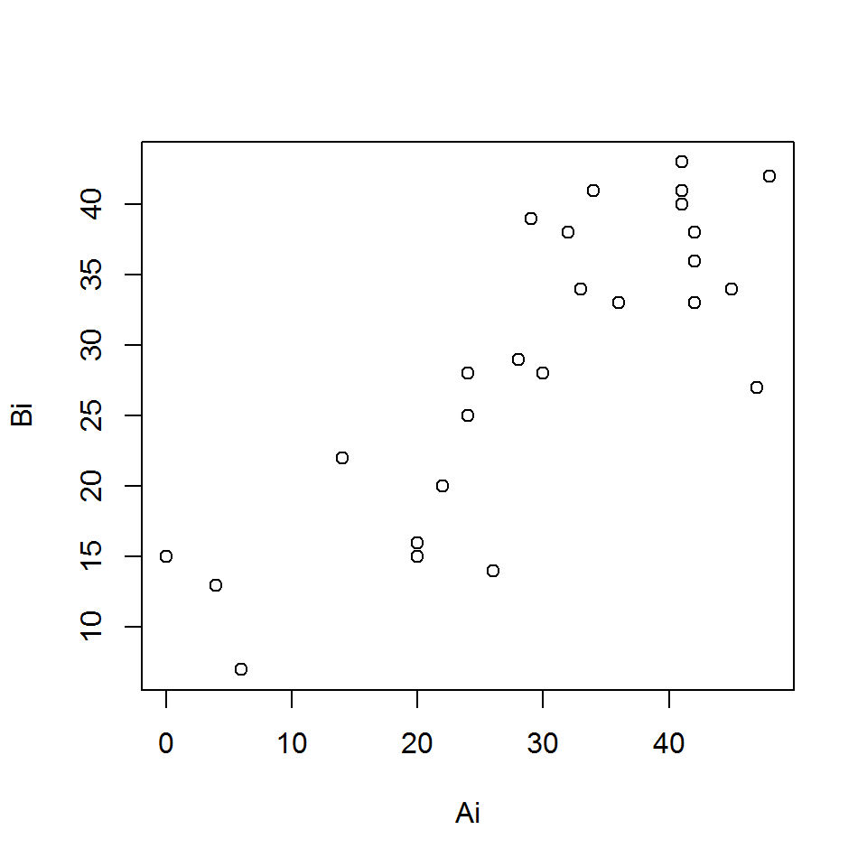

```r
Ai<-spatial$A
Bi<-spatial$B
plot(Ai,Bi)
```

```r
mean(Ai)
```

```
## [1] 29.65385
```

```r
mean(Bi)
```

```
## [1] 28.88462
```

```r
cov(spatial)
```

```
##          A        B
## A 178.3954 116.9585
## B 116.9585 113.7862
```

The parameter of primary interest is the variance of the variable $A$, $\sigma^{2}_{A}$. The sample variance is equal to $\hat{\sigma}^{2}_{A}=178.3954$.We use the function $ bcanon$ from the R package $bootstrap$ to calculate the $BC_a$ interval.

```r
x<-Ai
theta <- function(x){var(x)}
results <- bcanon(x,1000,theta,alpha=c(0.025,0.975))
```

A $95\%$ C.I is given by

```r
results
```

```
## $confpoints
##      alpha bca point
## [1,] 0.025  108.6846
## [2,] 0.975  298.7262
##
## $z0
## [1] 0.1814683
##
## $acc
## [1] 0.06124012
##
## $u
##  [1] 171.2433 184.0833 181.7900 185.8100 179.2233 179.2233 181.7900 179.2233 183.2900 180.2500
## [11] 175.6233 175.2100 161.5833 147.7233 185.3433 185.7100 185.0100 157.3100 185.5900 184.4433
## [21] 172.7900 180.2500 184.4433 185.2500 185.8233 180.2500
##
## $call
## bcanon(x = x, nboot = 1000, theta = theta, alpha = c(0.025, 0.975))
```

# 10 Bootstrap tests

In this chapter we focus on inference and, as before, the bootstrap mechanism should reflect the original data generation mechanism. In addition there is a second important rule: the bootstrap simulation should satisfy the null hypothesis.The idea is to generate (repeatedly) new bootstrap data, reflecting the null hypothesis, recalculate the test statistic and in this way to simulate the null distribution of the test statistic. These bootstrap test values can then be used to compute a p-value. We discussed in this chapter non parametric procedures for

- One sample tests.
- Two samples tests.

Other bootstrap tests (for different settings) will be discuused on different chapters.

## 10.1 The One sample problem

### 10.1.1 Classical tests under normality assumption

#### 10.1.1.1 Test for one population using $N(0,1)$

Assuming a normal population, the distribution of the sample mean under the null hypothesis is given by
$$\bar{z} \sim N(129,\sigma^{2}/n).$$
Therefore, the test statistic
$$t(z)=\frac{\bar{z}-129}{\sigma / \sqrt{n}},$$
follows a standard normal distribution. The P-value can be calculated by
$$\Phi \left ( \frac{86.9-129}{\sigma/ \sqrt{n}} \right ).$$
In practice, $\sigma$ is unknown so we use the estimate $\bar{\sigma}$,
$$\Phi \left ( \frac{86.9-129}{66.8/ \sqrt{7}} \right )=\phi(-1.67)=0.05.$$

#### 10.1.1.2 One sample t test

In R one sample t test for the hypotheses

$$H_{0}:\mu_{z}=129, H_{1}:\mu_{z} \le 129,$$
can be conducted using the function $t.test$.

```r
z <- c(94, 197, 16, 38, 99, 141, 23)
z
```

```
## [1]  94 197  16  38  99 141  23
```

```r
mean(z)
```

```
## [1] 86.85714
```

```r
sd(z)
```

```
## [1] 66.76683
```

```r
t.test(z,mu=129)$statistic
```

```
##         t
## -1.669984
```

```r
t.test(z,mu=129,alternative="less")
```

```
##
##  One Sample t-test
##
## data:  z
## t = -1.67, df = 6, p-value = 0.07298
## alternative hypothesis: true mean is less than 129
## 95 percent confidence interval:
##      -Inf 135.8942
## sample estimates:
## mean of x
##  86.85714
```

### 10.1.2 One sample bootstrap test

Recall that the bootstrap simulation should satisfy the null hypothesis. Suppose that we resample from the empirical distribution $\hat{F}$. Consider the following bootstrap algorithm

- Simulate $B$ samples of size $n$ with replacement from z.
- Calculate the test statistic values $t(z^*)_1, \ldots, t(z^*)_b, \ldots, t(z^*)_B$, independently under the null hypothesis model,
  $$t(z^*)_{b}=\frac{\bar{z^{*}}-129}{\bar{\sigma^{\star}} / \sqrt{n}},\;\;b=1,\ldots,B.$$
- Compute the Monte Carlo P-value:
  $$]
  p_{mc} = \frac{1+(\#\{t(z^*)_b \geq t\})}{B+1}.$$

The main problem is that the algorithm above dose not satisfy the null hypothesis $H_{0}:\mu_{z}=129$ since the mean of the empirical distribution is not 129.

#### 10.1.2.1 A non parametric bootstrap algorithm under $H_{0}$.

$\hat{F}$ is not an appropriate estimate for $F$ since it dose not obey $H_{0}$, the mean of $\hat{F}$ is not 129. We need to obtain an estimate for $F$ which has the mean of 129. This can be done by
$$\tilde{z}_{i}=z_{i}-\bar{z}+129.$$

The bootstrap algorithm for the one sample problem is as follows.

- Simulate $B$ samples of size $n$ with replacement from $\tilde{z}$.
- Calculate the test statistic values $t(z^*)_1, \ldots, t(z^*)_b, \ldots, t(z^*)_B$, independently under the null hypothesis model,
  $$t(z^*)_{b}=\frac{\bar{z^*}-129}{\bar{\sigma^*} / \sqrt{n}},\;\;b=1,\ldots,B.$$
- Compute the Monte Carlo P-value
  $$p_{mc} = \frac{1+(\#\{t(z^*)_b \geq t\})}{B+1}$$

#### 10.1.2.2 Implemention in R

In the first step we substruct $\bar{z}$ and add $\mu_{0}$ to the observed data.

```r
mz <- mean(z)
mz
```

```
## [1] 86.85714
```

```r
n <- length(z)
z.tilde <- z - mz + 129
mean(z.tilde)
```

```
## [1] 129
```

Note that $\bar{\tilde{z}}=129$. Nest we resample from $\tilde{z}$.

```r
nz<-length(z)
t.obs<-t.test(z,mu=129)$statistic
B<-5000
t.boot<-c(1:B)
for(b in 1:B)
{
z.b<-sample(z.tilde,size=nz,replace=T)
t.boot[b]<-t.test(z.b,mu=129)$statistic
}
```

Monte-carlo p-value is calculated by

```r
Pmc<-(1+sum(t.boot < t.obs))/(B+1)
Pmc
```

```
## [1] 0.09858028
```

Since Pmc > 0.05 we do not reject the null hypothesis. The distribution of the test statistics under the null hypothesis is shown below.

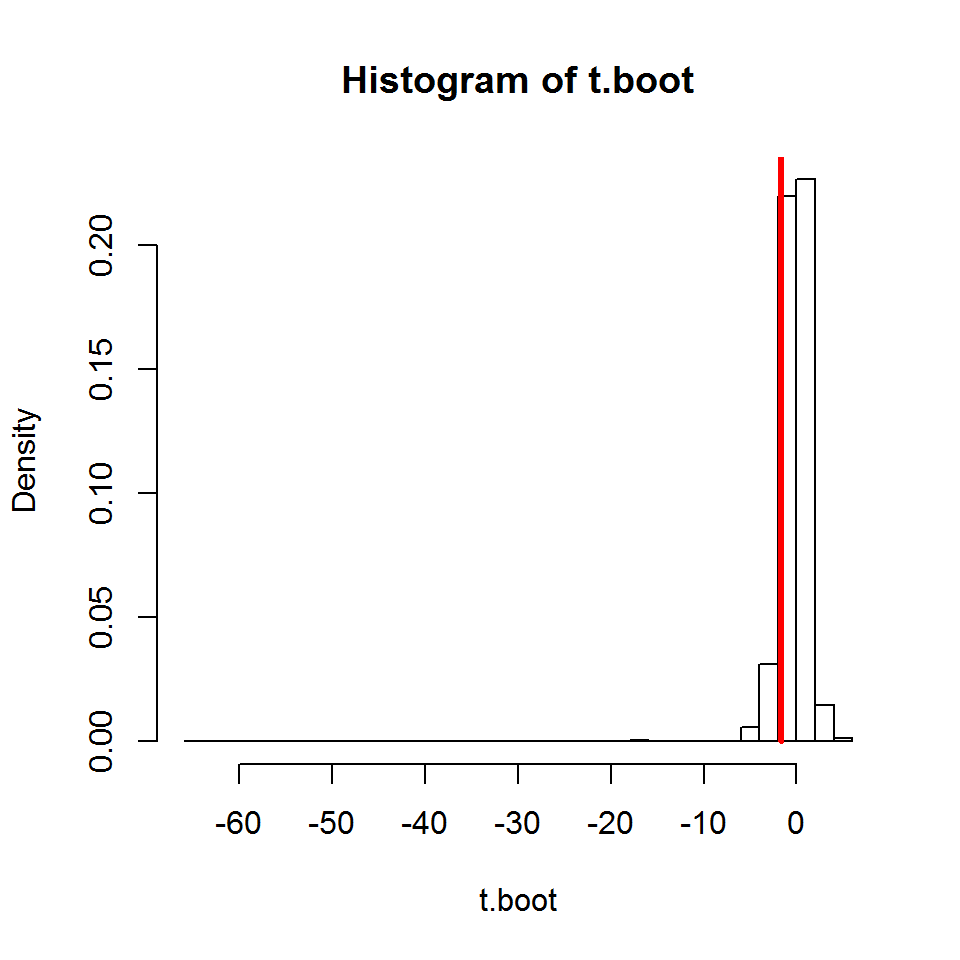

```r
hist(t.boot,nclass=50,probability=T)
lines(c(t.obs,t.obs),c(0,1),lwd=3,col=2)
```

## 10.2 The two samples problem

#### 10.2.0.1 Example: the mouse data - classical two sample t test

For illustraion, we use the mouse data and test that the mean of the control group is equal to the mean of the treatment group. Data are boxplot for the two groups are whon below.

```r
y <- c(10, 27, 31, 40, 46, 50, 52, 104, 146)
x <- c(16, 23, 38, 94, 99, 141, 197)
y
```

```
## [1]  10  27  31  40  46  50  52 104 146
```

```r
x
```

```
## [1]  16  23  38  94  99 141 197
```

```r
mean(y)
```

```
## [1] 56.22222
```

```r
mean(x)
```

```
## [1] 86.85714
```

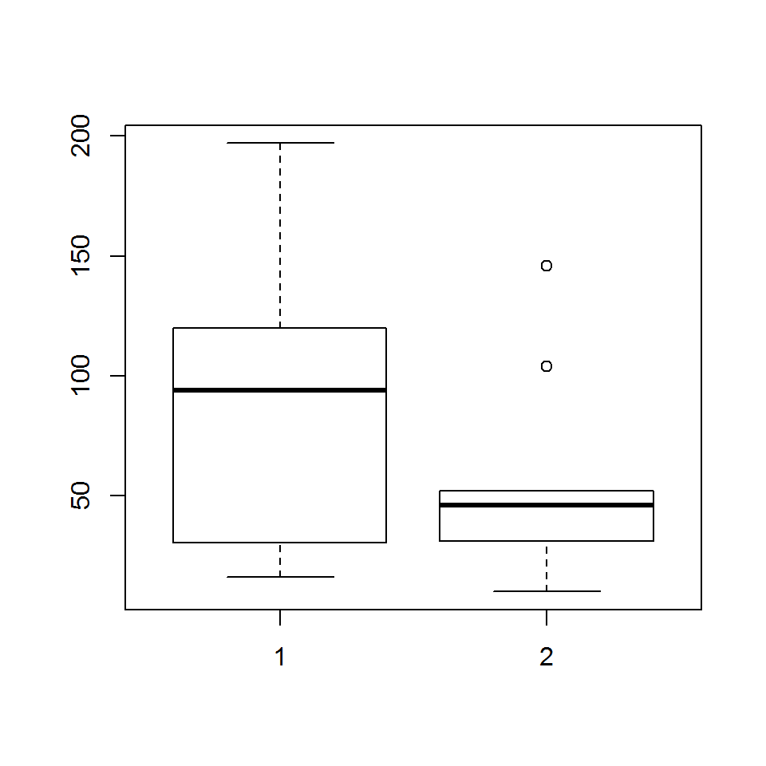

```r
boxplot(x,y)
```

A two sample t test is given by

```r
t.test(x,y,var.equal=TRUE)
```

```
##
##  Two Sample t-test
##
## data:  x and y
## t = 1.1214, df = 14, p-value = 0.281
## alternative hypothesis: true difference in means is not equal to 0
## 95 percent confidence interval:
##  -27.95786  89.22770
## sample estimates:
## mean of x mean of y
##  86.85714  56.22222
```

### 10.2.1 Bootstrap test (I)

#### 10.2.1.1 YouTube tutorial: two samples t-test

An example for the implementation of bootstrap procedure for two-samples t-test is given by Matthew E. Clapham in [YTBootstrap 6](https://www.youtube.com/watch?v=Kho4VuKmQdE). This YouTube tutorial covers also permutations test that we discussed in the next chapter of the book

#### 10.2.1.2 YouTube tutorial: bootstrap tests with R (the two-samples problem)

The tutorial by Mike Marin is focused on hypothesis testing in two-samples setting and discuss the implementation of a non parametric bootstrap procedure for two test statistics. See [YTBootstrap 7](https://www.youtube.com/watch?v=Zet-qmEEfCU).

#### 10.2.1.3 Using the mean difference as test statistic

As before the bootstrap mechanism should reflect the original data generation mechanism and, in this setting of testing hypotheses, there is a second important rule, namely the bootstrap simulation should satisfy the null hypothesis.

In practice, we draw a sample of size $n+m$ with replacement from $Z$. The first $n$ are considered to be observations from $F$ and the remaining $m$ are considered as observations from $G$.

We consider the following test statistic (see also the example in Mike Marin’s tutorial):

$$t(z)=\bar{x}-\bar{y}.$$

A non parametric bootstrap algorithm for testing $H_{0}:F=G$ is given by

- Simulate $B$ samples of size $m+n$ with replacement from z. The first $n$ are considered as  
  observations $x^{\star}$ and the remaining $m$ as observations $y^{\star}$.
- Calculate the test statistic values $t(z^*)_1, \ldots, t(z^*)_b, \ldots, t(z^*)_B$, independently under the null hypothesis model,
  $$t(z^*)_{b}=\bar{x^{*}}-\bar{y^{\star}},\;\;b=1,\ldots,B.$$
- Compute the Monte Carlo P-value
  $$p_{mc} = \frac{1+(\#\{t(z^*)_b \geq t\})}{B+1}.$$
  In R, we first need to define a new vector (z) that contains the joint sample.

```r
z <- c(x, y)
m <- length(x)
n <- length(y)
mn <- m + n
t.obs <- mean(x) - mean(y)
t.obs
```

```
## [1] 30.63492
```

Note that the test statistics is $\bar{x}-\bar{y}$. The non parametric bootstrap precedure is given below.

```r
B<-5000
t.boot<-c(1:B)
for(b in 1:B)
{
z.b<-sample(z,size=mn,replace=T)
x.b<-z.b[1:n]
y.b<-z.b[(n+1):mn]
t.boot[b]<-mean(x.b)-mean(y.b)
}
```

The distribution of the test statistics under $H_{0}$ is centered around zero.

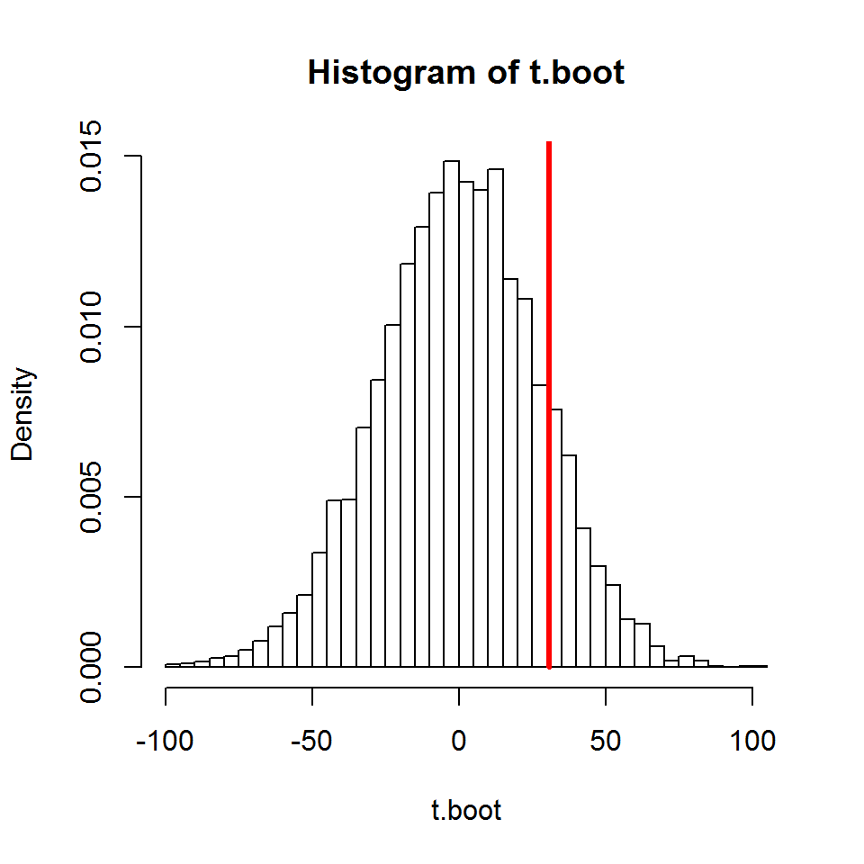

```r
hist(t.boot,nclass=50,probability=T)
lines(c(t.obs,t.obs),c(0,1),lwd=3,col=2)
```

The monte-carlo p-value for one sided alternative is equal to

```r
(sum(t.boot>t.obs)+1)/(B+1)
```

```
## [1] 0.1311738
```

#### 10.2.1.4 A two-samples t-test

Alternativly, we can use the usual two samples t-test statistic
$$t(z)=\frac{\bar{x}-\bar{y}}{\bar{\sigma}\sqrt{1/m+1/n}},$$

```r
t.obs <- t.test(x,y)$statistic
t.obs
```

```
##        t
## 1.059062
```

The non parametric bootstrap precedure for testing $H_{0}:F=G$ is as follows

- Simulate $B$ samples of size $m+n$ with replacement from z. The first $n$ are considered as  
  observations $x^{\star}$ and the remaining $m$ as observations $y^{\star}$.
- Calculate the test statistic values $t(z^*)_1, \ldots, t(z^*)_b, \ldots, t(z^*)_B$, independently under the null hypothesis model,
  $$t(z^*)_{b}=\frac{\bar{x^{*}}-\bar{y^{\star}}}{\bar{\sigma^{\star}}\sqrt{1/m+1/n}},\;\;b=1,\ldots,B.$$
- Compute the Monte Carlo P-value
  $$p_{mc} = \frac{1+(\#\{t(z^*)_b \geq t\})}{B+1}.$$

The procedure above can be implemented in R using the follwoing code

```r
B<-2500
t.boot<-c(1:B)
for(b in 1:B)
{
z.b<-sample(z,size=mn,replace=T)
x.b<-z.b[1:n]
y.b<-z.b[(n+1):mn]
t.boot[b]<-t.test(x.b,y.b)$statistic
}
```

The distribution of the test statistic under the null hypothesis and the bootstrap p value:

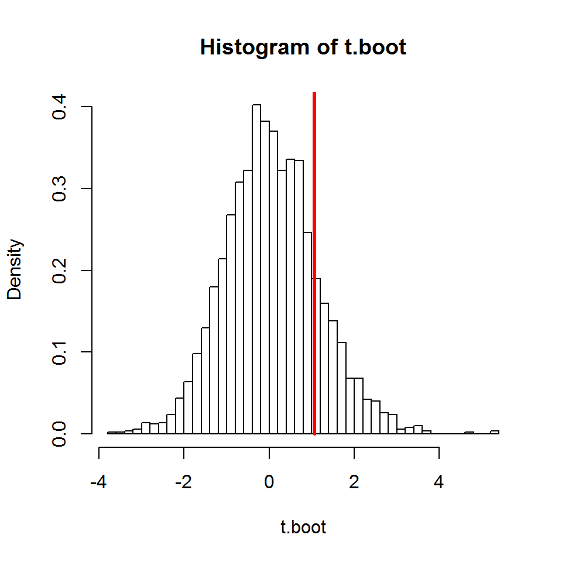

```r
hist(t.boot,nclass=50,probability=T)
lines(c(t.obs,t.obs),c(0,1),lwd=3,col=2)
```

```r
Pmc<-(1+sum(t.boot > t.obs))/(B+1)
Pmc
```

```
## [1] 0.1679328
```

The bootstrap p value is very similar to the two sample t test below

```r
t.test(x,y,alternative="greater",var.equal=TRUE)
```

```
##
##  Two Sample t-test
##
## data:  x and y
## t = 1.1214, df = 14, p-value = 0.1405
## alternative hypothesis: true difference in means is greater than 0
## 95 percent confidence interval:
##  -17.48178       Inf
## sample estimates:
## mean of x mean of y
##  86.85714  56.22222
```

### 10.2.2 Bootstrap test (II)

Tor this bootstrap algorithm both samples are transformed and centered around the overall mean of the joint sample $z$. In the sedonc step, we resample from $\tilde{x}$ and $\tilde{y}$. The bootstrap procedure is given below.

- Simulate $B$ samples of size $m$ and $n$ with replacement from $\tilde{x}$ and $\tilde{y}$.
- Calculate the bootstrap sample means $\bar{\tilde{x}}^{*}_{b}$ and $\bar{\tilde{y}}^{*}_{b}$
- Calculate the test statistic values $t(z^*)_1, \ldots, t(z^*)_b, \ldots, t(z^*)_B$, independently under the null hypothesis model,
  $$t(z^*)_{b}=\frac{\bar{x^{*}}-\bar{y^{\star}}}{\bar{\sigma^{\star}}\sqrt{1/m+1/n}},\;\;b=1,\ldots,B.$$
- Compute the Monte Carlo P-value
  $$p_{mc} = \frac{1+(\#\{t(z^*)_b \geq t\})}{B+1}.$$

For the mouse data, the above bootstrap algorithm is implemented in R in the follwing way. First we define $\tilde{x}$ and $\tilde{y}$.

```r
y <- c(10, 27, 31, 40, 46, 50, 52, 104, 146)
x <- c(16, 23, 38, 94, 99, 141, 197)
z<-c(x,y)
m <- length(x)
n <- length(y)
my<-mean(y)
mx<-mean(x)
mz<-mean(z)
x.tilde<-x-mx+mz
y.tilde<-y-my+mz
mean(x.tilde)
```

```
## [1] 69.625
```

```r
mean(y.tilde)
```

```
## [1] 69.625
```

Note that $\bar{\tilde{x}}=\bar{\tilde{y}}=\bar{z}$ as requested. Next we resample with replacent from both $\tilde{x}$ and $\tilde{y}$.

```r
t.obs <- t.test(x,y)$statistic
t.obs
```

```
##        t
## 1.059062
```

```r
B<-1000
t.boot<-c(1:B)
for(b in 1:B)
{
x.b<-sample(x.tilde,m,replace=TRUE)
y.b<-sample(y.tilde,n,replace=TRUE)
t.boot[b]<-t.test(x.b,y.b)$statistic
}
```

The distribution of the test statistics and the monte-carlo p value.

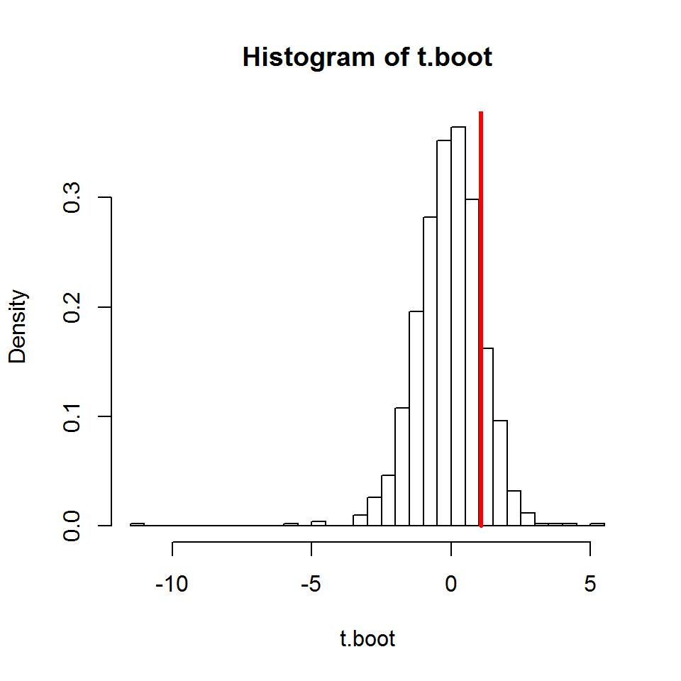

```r
hist(t.boot,nclass=50,probability=T)
lines(c(t.obs,t.obs),c(0,1),lwd=3,col=2)
```

```r
Pmc<-(1+sum(t.boot > t.obs))/(B+1)
Pmc
```

```
## [1] 0.1378621
```

# 11 The correlation test

The cars data give the speed of 50 cars and the distances taken to stop. The data were recorded in the 1920s.

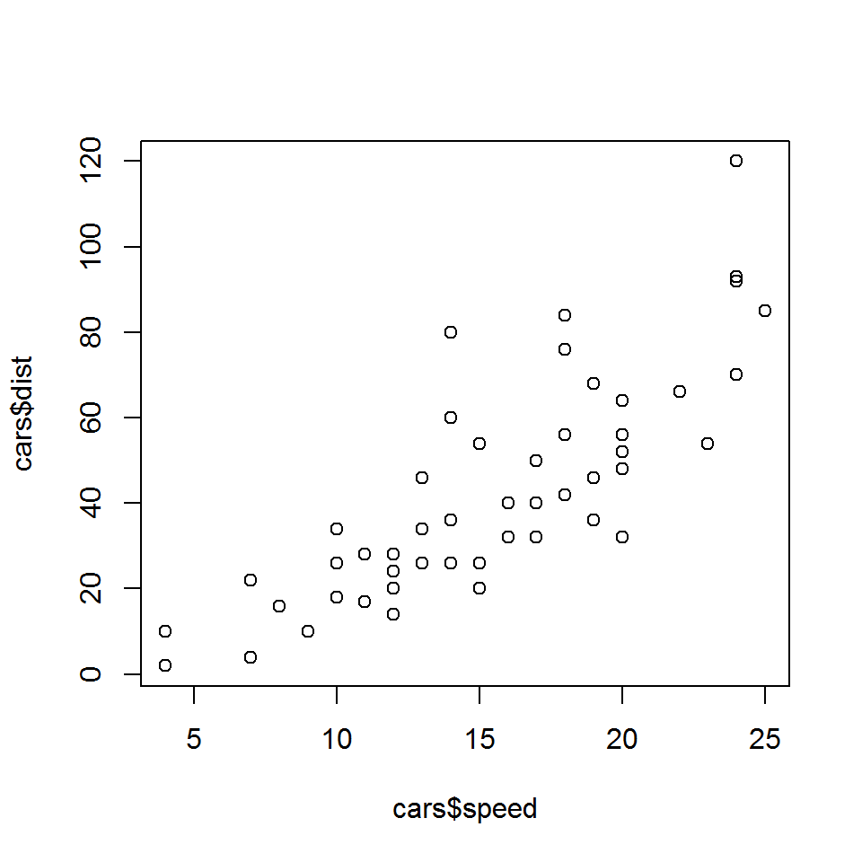

```r
plot(cars$speed,cars$dist)
```

Let $x$ be the car speed and $y$ be the stopping distance.

```r
x<-cars$speed
y<-cars$dist
```

The parameter of primary interest is the correlation $\rho(x,y)$. The sample correlation is equal to

```r
rho<-cor(x,y)
rho
```

```
## [1] 0.8068949
```

Our aim is to test the null hypothesis
$$H_{0}:\rho=0.$$

## 11.1 Non parametric bootstrap

Given the pairs $(x_1,y_1), \ldots, (x_n,y_n)$, a possible test statistic, consider the above null hypothes that $X$ and $Y$ are independent can be based on the sample correlation $\hat{\rho}$.The nonparametric bootstrap test for zero correlation does not assume anything about the joint and marginal distributions of $x$ and $y$. A way to generate new uncorrelated $x$ and $y$ values is to resample both separately, with replacement from their empirical distribution.

```r
n<-length(x)
B<-1000
coeff.boot<-c(1:B)
for(b in 1:B)
{
x.boot<- sample(x,size=n,replace=TRUE)
y.boot<- sample(y,size=n,replace=TRUE)
coeff.boot[b]<-cor(x.boot,y.boot)
}
```

The distribution of the test statistic under $H_{0}$ is given by

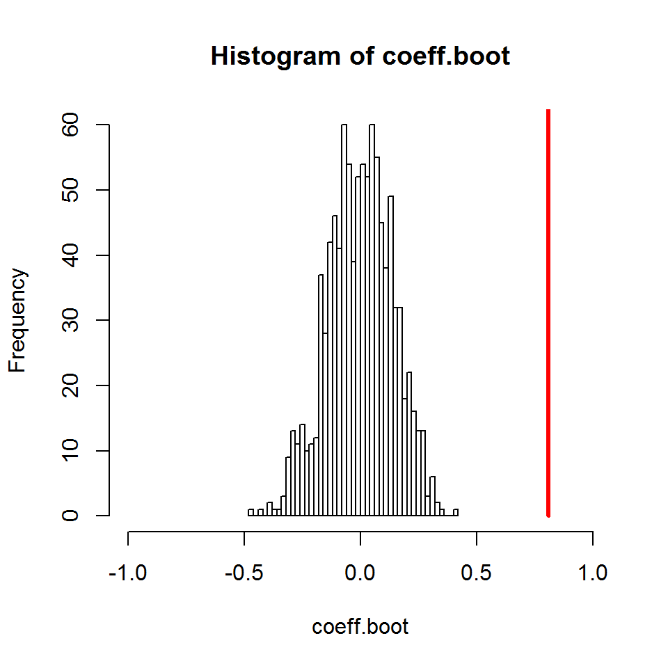

```r
hist(coeff.boot,nclass=50,xlim=c(-1,1))
lines(c(rho,rho),c(0,500),col=2,lwd=3)
```

with monte-carlo p value given by

```r
(1+sum(abs(coeff.boot)>rho))/(B+1)
```

```
## [1] 0.000999001
```

Note that the bootstrap procedure above is NOT the same as the non-parametric bootstrap procedure for the case that a confidence interval for $\rho$ is of interest. For this case we need to resamples pairs and the bootstrap algorithm is implemented as follows:

```r
n<-length(x)
index<-c(1:n)
B<-1000
coeff.boot<-c(1:B)
index<-c(1:n)
for(b in 1:B)
{
index.b<- sample(index,size=n,replace=TRUE)
x.boot<- x[index.b]
y.boot<- y[index.b]
coeff.boot[b]<-cor(x.boot,y.boot)
}
```

The estimate for the distribution of $\hat{rho}$ is shown below.

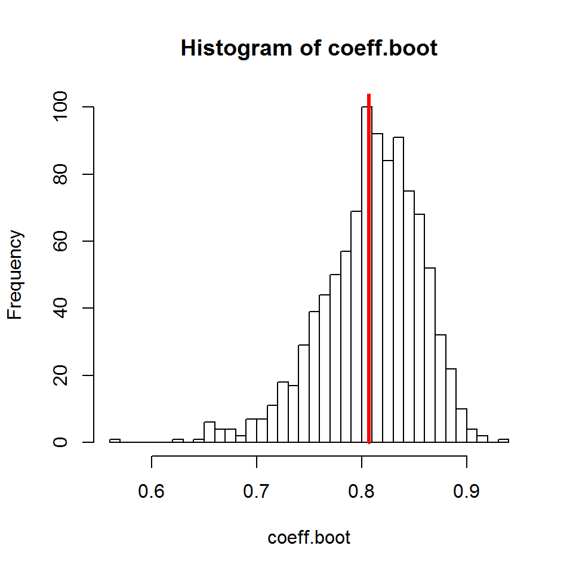

```r
hist(coeff.boot,nclass=50)
lines(c(rho,rho),c(0,500),col=2,lwd=3)
```